# Everybody needs good neighbours: movement and conspecific association in a reintroduced mesopredator

Wilson B A, Evans M J, Rapley S, Gordon I J, Wimpenny C, Newport J, & Manning A D

Jun 23, 2024

# 1 **Background**

We investigated whether conspecific associations between seven maternal **resident** (descedents of founders or reinforcers) eastern quolls (*Dasyurus viverrinus*, *murunguny* in the Indigenous Ngunnawal language) affected the establishment of eight maternal **reinforcers** (translocated from Tasmania to reinforce demographic, behavioural, and genetic diversity in the population) at [Mulligans Flat Woodland Sanctuary (MFWS)](https://www.mulligansflat.org.au/), a fenced reserve in the Australian Capital Territory.

We used GPS collars to quantify **distances travelled**, **home** and **core ranges**, habitat use (**nocturnal activity** and **diurnal denning**), and **conspecific associations**. We compared these measures across three distinct periods:

1. Baseline period (residents only, days 3-21),
2. Release period (both cohorts, days 22-32), and
3. Settlement period (reinforcers only, days 33-52).

# 2 **Setup**

First, we installed the [pacman Package Management Tool](https://cran.r-project.org/web/packages/pacman/index.html), which allows us to install and load subsequent packages in a condensed and efficient way.

```r
#install.packages(pacman)
```

```r
# Install and load required packages
pacman::p_load(adehabitatHR, adehabitatLT, AICcmodavg, brglm, corrplot, data.table, dplyr, ggplot2, ggpmisc, ggpubr, ggspatial, grid, gridExtra, gtools, janitor, lme4, lubridate, MuMIn, plotrix, raster, readxl, rgdal, RODBC, scales, sf, sp, tidyr, tidyverse, viridis, wildlifeDI)
```

# 3 **Data curation**

## 3.1 Prepare data

Firstly, we load the required packages and read in our GPS coordinate and environment data.

```r
# Assign raw data filename to an object
raw_data <- "input/data.xlsx"

# Read in GPS data
gps <- read_excel(raw_data, sheet="coordinates") %>%
  clean_names() %>%
  na.omit() %>%
  mutate(date_time = as.POSIXct(aest, format="%d/%m/%Y %H:%M")) %>%
  mutate(date = as.Date(date_time, format="%d/%m/%Y")) %>%
  rename(temp = temperature)

# Read in environmental data
enviro <- read_excel(raw_data, sheet="environment") %>%
  clean_names() %>%
  mutate(date = as.Date(as.POSIXct(day, format="%d/%m/%Y")))

# Combine GPS and environmental data
coords <- left_join(gps, enviro, by="date")
```

Since (a) eastern quolls are active at night and (b) we configured the GPS units to collect fixes between 1700 and 0700 hours, we have simplified the categorisation of a ‘quoll day’ by subtracting 12 hrs from the real time each of fix so they fall on the same date. We also categorised each fix by `period`.

```r
coords <- coords %>%
  # Minus 12 hrs from date_time
  mutate(date_time_12hr = as.character(date_time-12*60*60)) %>%
  mutate(date_12hr = as.Date(date_time_12hr)) %>%
  # Create day of the year variable (1-365)
  mutate(day_12hr = as.numeric(yday(date_12hr))) %>%
  # Create study night variable (3-52)
  mutate(night_12hr = (as.numeric(yday(date_12hr))-157)) %>%
  # Remove irrelevant dates
  subset(night_12hr >=3 & night_12hr <=52) %>%
  mutate(period=ifelse(night_12hr >=3 & night_12hr <=21,
                       'Baseline',
                ifelse(night_12hr >=22 & night_12hr <=32,
                       'Release',
                ifelse(night_12hr >=33 & night_12hr <=52,
                       'Settlement', NA)))) %>%
  subset(ifelse(cohort=="Resident", night_12hr <=32,
                night_12hr >=22))

# Display range of study nights (should be range 3–52)
sort(unique(coords$night_12hr))
```

```
##  [1]  3  4  5  6  7  8  9 10 11 12 13 14 15 16 17 18 19 20 21 22 23 24 25 26 27
## [26] 28 29 30 31 32 33 34 35 36 37 38 39 40 41 42 43 44 45 46 47 48 49 50 51 52
```

1. Was not working correctly (problem with `Deployment`),
2. Was not deployed on a `Quoll`,
3. Was deployed on a quoll which was caught in a trap, and
4. Failed to gain a fix (`Longitude`=0).

```r
# Filter coordinates into four dataframes
coords_q <- subset(coords, quoll!=0)
coords_p <- subset(coords_q, deployment=="Field")
coords_t <- subset(coords_p, trap!="Trap")
coords_l <- subset(coords_t, longitude!=0) %>%
  mutate(easting = as.numeric(easting),
         northing = as.numeric(northing))
```

## 3.2 Clip by MFWS fence

Next, we use the [National Vegetation Information System (version 6.0)](http://www.environment.gov.au/fed/catalog/search/resource/details.page?uuid=%7Bab942d6d-9efd-4cf2-bec7-4c1521b83803%7D) major extant vegetation groups polygon (adapted for MFWS, see Habitat use section) to classify points as **inside** or **outside** the sanctuary.

```r
mf_fence <- st_read("input/mfws_fence.shp", quiet=TRUE) %>%
  # Set projection using sf
  st_set_crs("EPSG:32755") %>%
  st_transform("EPSG:4326")

coords_sp <- SpatialPointsDataFrame(
  data.frame(coords_l$longitude, coords_l$latitude),
  coords_l, proj4string=CRS("EPSG:4326")) %>%
  st_as_sf()

# Filter fixes to those inside MFWS
coords_filt <- st_filter(coords_sp, mf_fence)

nvis <- st_read("input/mfws_nvis_vegetation_groups.shp",
                quiet=TRUE) %>%
  st_transform("EPSG:4326")

nvis_info <- read.csv("input/mfws_nvis_vegetation_groups.csv") %>%
  clean_names() %>%
  dplyr::select(c(id, nvis_habitat=mvg_name,
                  mfws_habitat=mfws_name))

# Annotate polygon data to GPS df
coords_annotated <- coords_sp %>%
  mutate(id=as.numeric(st_intersects(coords_sp, nvis))) %>%
  st_drop_geometry() %>%
  left_join(nvis_info, by="id") %>%
  mutate(fence=factor(ifelse(!is.na(mfws_habitat),
                             "Inside", "Outside"),
                      levels=c("Inside", "Outside")))
```

We checked this worked by mapping the coordinates.

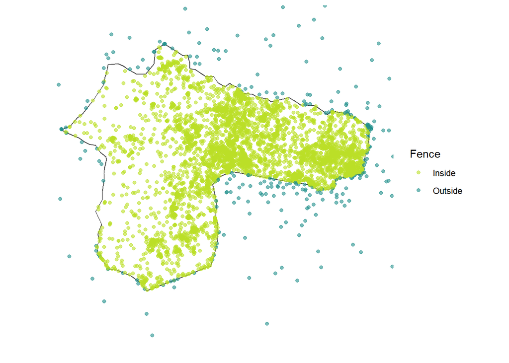

```r
# Read in MFWS shapefile
mfws <- readOGR(dsn="input/mfws_fence.shp", verbose=FALSE) %>%
  # Set projection using rgdal
  spTransform(CRS("+proj=utm +zone=55 +datum=WGS84")) %>%
  # Transform from from sp to df
  fortify(verbose=FALSE) %>%
  mutate(lat=as.numeric(lat + 10000000),
         long=as.numeric(long))

# Plot coordinates
ggplot() +
  geom_path(mfws, mapping=aes(x=long, y=lat,
                              group=group), col="grey30") +
  geom_point(coords_annotated,
             mapping=aes(x=easting, y=northing,
                         col=fence), alpha=0.6) +
  coord_sf(xlim=c(695750, 699250),
           ylim=c(6104250, 6107750)) +
  theme(panel.grid.major=element_blank(),
        panel.grid.minor=element_blank(),
        panel.border=element_blank(),
        panel.background=element_rect(fill="white"),
        axis.text.x=element_blank(),
        axis.text.y=element_blank(),
        axis.ticks.x=element_blank(),
        axis.ticks.y=element_blank(),
        legend.key=element_blank()) +
  scale_colour_manual(values=viridis(3, begin=0.9,
                                     end=0.1), name="Fence") +
  xlab("") + ylab("")
```

## 3.3 Filter by covariates

Even after filtering there are still erroneous fixes (i.e., outside the fence). Next we model whether the remaining four variables contribute to whether a fix is inside or outside the sanctuary.

5. `Duration` taken for the GPS to acquire a fix (max 75 seconds),
6. `Temperature` (°C) of the GPS unit
7. H`DOP` (horizontal dilution of precision)
8. Number of `Satellites` used to acquire a fix

Note that while `Altitude` also had a significant effect, this is because the areas surrounding MFWS have higher terrain, so we did not include this variable.

```r
# Print model summary statistics for inside/outside fix predictors
mod_null <- glm(fence ~ 1, family=binomial(link=logit),
                data=coords_annotated)

mod_cov <- glm(fence ~ duration + temp + dop + satellites,
               family=binomial(link=logit),
               data=coords_annotated)

# Calculate AIC of each model
aictab(cand.set = list(mod_null, mod_cov),
       modnames = c('Null', 'Covariates'))
```

```
##
## Model selection based on AICc:
##
##            K    AICc Delta_AICc AICcWt Cum.Wt       LL
## Covariates 5 2346.87       0.00      1      1 -1168.43
## Null       1 3026.55     679.69      0      1 -1512.28
```

All four variables significantly predicted whether a point was inside or outside the fence, so we boxplotted each variable to determine whether points inside where generally higher or lower for each variable.

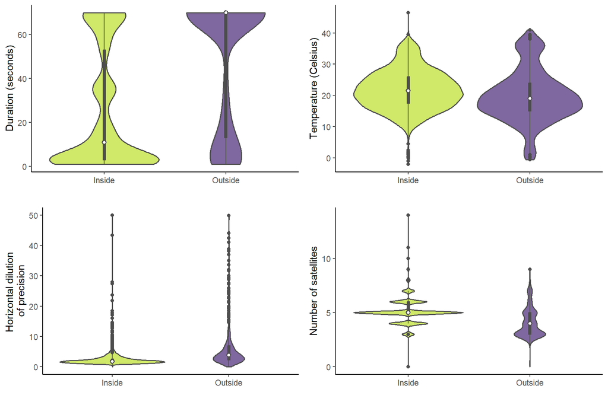

```r
# Plot frequency of coordinates inside/outside MFWS
duration <- ggplot(coords_annotated,
                   mapping=aes(x=fence, y=duration,
                               fill=fence, col=fence)) +
  geom_violin(col="grey30", alpha=0.7, lwd=0.6) +
  geom_boxplot(col="grey30", fill="grey30",
               width=0.02, lwd=0.5) +
  stat_summary(fun="median", geom="point",
               col="grey30", fill="white",
               shape=21, size=1.5, stroke=1) +
  theme(legend.position="none",
        axis.line=element_line(colour="black"),
        panel.background=element_rect(fill="white")) +
  scale_colour_manual(values=viridis(2, begin=0.9, end=0.1)) +
  scale_fill_manual(values=viridis(2, begin=0.9, end=0.1)) +
  xlab("") + ylab("Duration (seconds)")

# Plot frequency of coordinates inside/outside MFWS
temperature <- ggplot(coords_annotated,
                      mapping=aes(x=fence, y=temp, fill=fence)) +
  geom_violin(col="grey30", alpha=0.7, lwd=0.6) +
  geom_boxplot(col="grey30", fill="grey30",
               width=0.02, lwd=0.5) +
  stat_summary(fun="median", geom="point",
               col="grey30", fill="white",
               shape=21, size=1.5, stroke=1) +
  theme(legend.position="none",
        axis.line=element_line(colour="black"),
        panel.background=element_rect(fill="white")) +
  scale_colour_manual(values=viridis(2, begin=0.9, end=0.1)) +
  scale_fill_manual(values=viridis(2, begin=0.9, end=0.1)) +
  xlab("") + ylab("Temperature (Celsius)")

# Plot frequency of coordinates inside/outside MFWS
hdop <- ggplot(coords_annotated, mapping=aes(x=fence, y=dop,
                                             fill=fence)) +
  geom_violin(col="grey30", alpha=0.7, lwd=0.6) +
  geom_boxplot(col="grey30", fill="grey30",
               width=0.02, lwd=0.5) +
  stat_summary(fun="median", geom="point",
               col="grey30", fill="white",
               shape=21, size=1.5, stroke=1) +
  theme(legend.position="none",
        axis.line=element_line(colour="black"),
        panel.background=element_rect(fill="white")) +
  scale_colour_manual(values=viridis(2, begin=0.9, end=0.1)) +
  scale_fill_manual(values=viridis(2, begin=0.9, end=0.1)) +
  xlab("") + ylab("Horizontal dilution \nof precision")

# Plot frequency of coordinates inside/outside MFWS
satellites <- ggplot(coords_annotated,
                     mapping=aes(x=fence, y=satellites,
                                 fill=fence)) +
  geom_violin(col="grey30", alpha=0.7, lwd=0.6) +
  geom_boxplot(col="grey30", fill="grey30",
               width=0.02, lwd=0.5) +
  stat_summary(fun="median", geom="point",
               col="grey30", fill="white",
               shape=21, size=1.5, stroke=1) +
  theme(legend.position="none",
        axis.line=element_line(colour="black"),
        panel.background=element_rect(fill="white")) +
  scale_colour_manual(values=viridis(2, begin=0.9, end=0.1)) +
  scale_fill_manual(values=viridis(2, begin=0.9, end=0.1)) +
  xlab("") + ylab("Number of satellites")

# Combine plots
covariates <- ggarrange(duration, temperature, hdop, satellites,
                        ncol=2, nrow=2, hjust=-0.1, vjust=1.5,
                        label.x=0.89, label.y=0.99, #library(ggpubr)
                        font.label=list(size=10, face="bold",
                                        color="black"))
# Display combined plot
print(covariates)
```

Based on this exploration, we filtered fixes that were in the first or third quartile for the ‘inside’ fixes, as follows:

5. `duration` ≤ Q3 (54 seconds)
6. `temp`erature ≥ Q1 (17°C)
7. H`DOP` ≤ Q3 (2.6)
8. `satellites` ≥ Q1 (5)

After filtering the fixes by all eight variables, there were only 21 ‘outside’ fixes left, which we removed manually.

```r
# Subset coordinates to determine how many were removed by each threshold
coords_d <- subset(coords_annotated, duration<=54)
coords_c <- subset(coords_d, temp>=17)
coords_h <- subset(coords_c, dop<=2.6)
coords_s <- subset(coords_h, satellites>=5)
coords_f <- subset(coords_s, fence=="Inside") %>%
    mutate(cohort=factor(cohort, levels=c("Resident", "Reinforcer")))

# Save df as csv
write.csv(coords_f, "output/coordinates curated.csv")
```

Below is a tabulated summary of the fixes removed by each variable’s threshold.

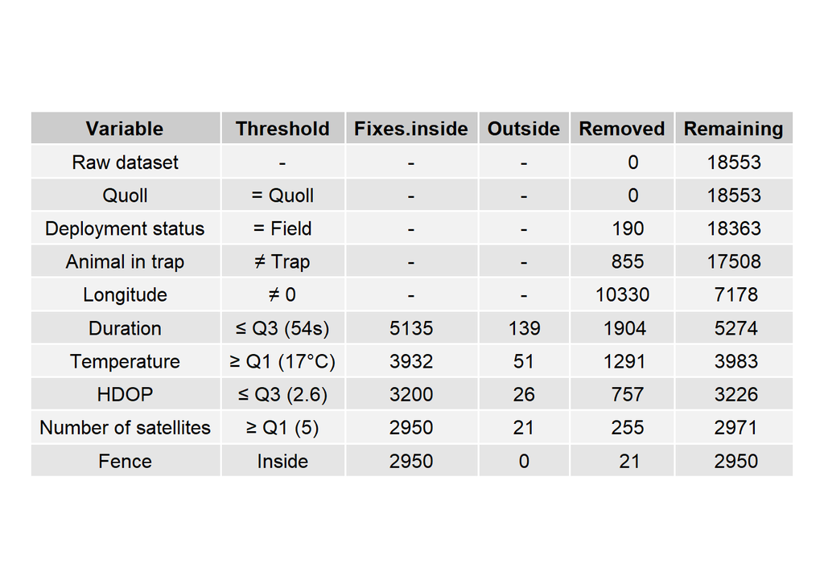

```r
# Generate table of fixes removed by each threshold
table <- data.frame("Variable"=c("Raw dataset", "Quoll",
                                 "Deployment status",
                                 "Animal in trap", "Longitude",
                                 "Duration", "Temperature", "HDOP",
                                 "Number of satellites", "Fence"),
  "Threshold"=c("-", "= Quoll", "= Field", "≠ Trap", "≠ 0", "≤ Q3 (54s)",
                "≥ Q1 (17°C)", "≤ Q3 (2.6)", "≥ Q1 (5)", "Inside"),
  "Fixes inside"=c("-", "-", "-", "-", "-",
                   sum(coords_d$fence=="Inside"),
                   sum(coords_c$fence=="Inside"),
                   sum(coords_h$fence=="Inside"),
                   sum(coords_s$fence=="Inside"),
                   sum(coords_f$fence=="Inside")),
  "Outside"=c("-", "-", "-", "-", "-",
              sum(coords_d$fence=="Outside"),
              sum(coords_c$fence=="Outside"),
              sum(coords_h$fence=="Outside"),
              sum(coords_s$fence=="Outside"),
              sum(coords_f$fence=="Outside")),
  "Removed"=c(nrow(coords)-nrow(coords),
              nrow(coords)-nrow(coords_q),
              nrow(coords_q)-nrow(coords_p),
              nrow(coords_p)-nrow(coords_t),
              nrow(coords_t)-nrow(coords_l),
              nrow(coords_l)-nrow(coords_d),
              nrow(coords_d)-nrow(coords_c),
              nrow(coords_c)-nrow(coords_h),
              nrow(coords_h)-nrow(coords_s),
              nrow(coords_s)-nrow(coords_f)),
  "Remaining"=c(nrow(coords), nrow(coords_q),
                nrow(coords_p), nrow(coords_t),
                nrow(coords_l), nrow(coords_d),
                nrow(coords_c), nrow(coords_h),
                nrow(coords_s), nrow(coords_f)))

curation_table <- tableGrob(table, rows=NULL)
grid.draw(curation_table)
```

# 4 **Distance**

We calculated the linear `distance` (metres) between consecutive locations divided by the number of fixes, to account for the varying number of positions and the fact that accuracy increases with increasing number of fixes.

## 4.1 **Data curation**

```r
# Read in data
data <- read.csv("output/coordinates curated.csv")

# Create vector of quoll identities
quolls <- unique(sort(data$name))

# Create empty df for loop to populate
distance_fix <- data.frame()

# Loop calculating linear distance between locations for each quoll
for(i in quolls){
  quolls <- subset(data, name==i)
  quolls$name <- factor(quolls$name) #converts to factor

  night <- as.POSIXct(strptime(as.character(quolls$date_time_12hr),
                               format="%Y-%m-%d %H:%M")) #converts date
  data.xy=quolls[c("easting", "northing")]
  xysp <- SpatialPoints(data.xy) #class Spatial Points for fixes
  proj4string(xysp) <- CRS("+proj=utm +zone=55 +datum=WGS84")
  sppt <- data.frame(xysp) #spatial df
  idsp <- data.frame(quolls$name) #spatial df with ids
  merge <- data.frame(idsp) #merges id and date in spatial df
  coordinates(merge) <- sppt #adds id and date df to spatial df
  move <- as.ltraj(xy=quolls[,c("easting","northing")],
                   date=night, id=idsp) #library(adehabitatLT) stores movements

  distance <- move[[1]]$dist #distance in metres
  quolls <- cbind(quolls, distance)
  distance_fix <- rbind(distance_fix, quolls)
}
```

Here we used distance per fix to calculate distance per night (adjusted for number of fixes), and combine the environmental data to use as random effects in our modelling.

```r
# Calculate distance travelled per study night
distance_night <- distance_fix %>% #distance per night
  mutate(distance = as.numeric(distance/1000), #gives kilometres
         night_12hr = as.numeric(night_12hr)) %>%
  group_by(cohort, period, morph, name, date_12hr, night_12hr) %>%
  summarise(distance = sum(distance),
            fixes = length(name)) %>% #to adjust for number of fixes
  mutate(distance_fix = distance/fixes,
         distance_night = distance,
         cohort = factor(cohort, levels=c("Resident","Reinforcer"))) %>%
  na.omit()

data <- distance_night %>%
  na.omit() %>%
  mutate(date_12hr = as.POSIXct(strptime(date_12hr,
                                         format="%Y-%m-%d",
                                         tz="Australia/Sydney")))

# Read in environmental covariates
enviro <- read_excel(raw_data, sheet="environment") %>%
  clean_names() %>%
  mutate(date_12hr = as.POSIXct(strptime(day, format="%Y-%m-%d"))) %>%
  subset(date_12hr>"2018-06-07" & date_12hr<"2018-07-31") %>%
  mutate_at(c(2:5), as.numeric)

# Join coordinate and environmental dfs
model_data <- as.data.frame(left_join(data, enviro, by="date_12hr"))
```

## 4.2 **Models**

```r
# Print model statistics for fixes and random predictors
round(coef(summary(lmer(distance_fix ~ morph + (period*cohort) +
                (1|name) + (1|precip) + (1|min_temp) +
                (1|moon), data=model_data))), digits=3)
```

```
##                  Estimate Std. Error t value
## (Intercept)         0.189      0.043   4.352
## morphFawn           0.041      0.046   0.887
## periodRelease      -0.042      0.046  -0.914
## periodSettlement   -0.170      0.060  -2.860
## cohortReinforcer    0.152      0.062   2.444
```

```r
summary(lmer(distance_fix ~ morph + (period*cohort) +
                (1|name) + (1|precip) + (1|min_temp) +
                (1|moon), data=model_data))
```

```
## Linear mixed model fit by REML ['lmerMod']
## Formula: distance_fix ~ morph + (period * cohort) + (1 | name) + (1 |
##     precip) + (1 | min_temp) + (1 | moon)
##    Data: model_data
##
## REML criterion at convergence: -40.6
##
## Scaled residuals:
##     Min      1Q  Median      3Q     Max
## -1.7728 -0.5037 -0.2050  0.1811  5.7208
##
## Random effects:
##  Groups   Name        Variance Std.Dev.
##  moon     (Intercept) 0.000000 0.00000
##  min_temp (Intercept) 0.001391 0.03730
##  name     (Intercept) 0.005183 0.07199
##  precip   (Intercept) 0.000000 0.00000
##  Residual             0.043916 0.20956
## Number of obs: 293, groups:  moon, 49; min_temp, 35; name, 15; precip, 10
##
## Fixed effects:
##                  Estimate Std. Error t value
## (Intercept)       0.18875    0.04337   4.352
## morphFawn         0.04057    0.04576   0.887
## periodRelease    -0.04230    0.04628  -0.914
## periodSettlement -0.17029    0.05954  -2.860
## cohortReinforcer  0.15185    0.06214   2.444
##
## Correlation of Fixed Effects:
##             (Intr) mrphFw prdRls prdStt
## morphFawn   -0.594
## periodReles -0.227  0.029
## perdSttlmnt -0.173  0.021  0.748
## cohrtRnfrcr -0.249 -0.068 -0.572 -0.663
## fit warnings:
## fixed-effect model matrix is rank deficient so dropping 2 columns / coefficients
## optimizer (nloptwrap) convergence code: 0 (OK)
## boundary (singular) fit: see help('isSingular')
```

```r
# Print model statistics for fixes and random predictors
round(coef(summary(lmer(distance_night ~ morph + (period*cohort) +
                (1|name) + (1|precip) + (1|min_temp) +
                (1|moon), data=model_data))), digits=3)
```

```
##                  Estimate Std. Error t value
## (Intercept)         1.251      0.317   3.943
## morphFawn           0.528      0.340   1.551
## periodRelease       0.406      0.270   1.504
## periodSettlement   -0.229      0.349  -0.656
## cohortReinforcer    0.222      0.419   0.530
```

## 4.3 Summary statistics

```r
# Print mean and standard error statistics
data.frame(Measure=c("Distance per fix:", "Distance per night:"),
           Mean=c(mean(model_data$distance_fix),
                  mean(model_data$distance_night)),
           SE=c(std.error(model_data$distance_fix),
                std.error(model_data$distance_night)))
```

```
##               Measure      Mean         SE
## 1   Distance per fix: 0.2294317 0.01320538
## 2 Distance per night: 1.7461487 0.08076781
```

```r
# Print mean and standard error statistics
model_data %>%
  group_by(period) %>%
  summarise(mean=mean(distance_night),
            se=std.error(distance_night))
```

```
## # A tibble: 3 × 3
##   period      mean     se
##   <chr>      <dbl>  <dbl>
## 1 Baseline    1.53 0.0920
## 2 Release     2.15 0.176
## 3 Settlement  1.60 0.152
```

## 4.4 Plot

Finally, we plot mean distance by study period.

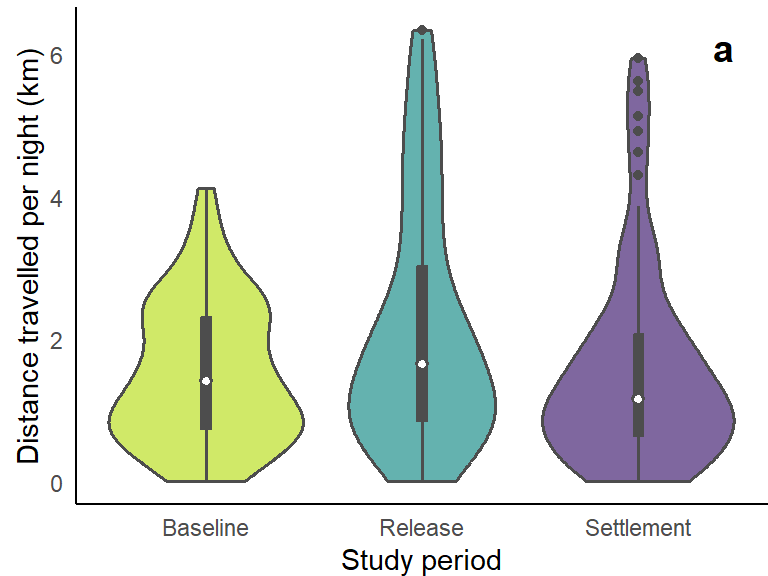

```r
dist_plot <- ggplot(data=distance_night,
                      aes(x=period, y=as.numeric(distance))) +
  geom_violin(aes(fill=period), col="grey30",
              alpha=0.7, lwd=0.6)

# Plot mean distances by study period
dist_plot <- ggplot(data=distance_night,
                      aes(x=period, y=as.numeric(distance))) +
  geom_violin(aes(fill=period), col="grey30",
              alpha=0.7, lwd=0.6) +
  geom_boxplot(col="grey30", fill="grey30",
               width=0.04, lwd=0.6) +
  stat_summary(fun="median", geom="point",
               col="grey30", fill="white",
               shape=21, size=1.5, stroke=1) +
  annotate(geom="text", x=3.4, y=6.1, label="a", fontface="bold", size=5) +
  theme(panel.grid.major=element_blank(),
        panel.grid.minor=element_blank(),
        panel.background=element_rect(fill="white"),
        plot.margin=unit(c(0.1, 0, 0, 0.2), "cm"),
        axis.line=element_line(colour="black"),
        axis.ticks.x=element_blank(),
        axis.ticks.y=element_blank(),
        legend.position="none") +
  scale_fill_manual(values=viridis(3, begin=0.9, end=0.1)) +
  xlab("Study period") + ylab("Distance travelled per night (km)")
print(dist_plot)
```

We will add to a grid of figures along with the home and core range results below.

# 5 **Range**

## 5.1 Home and core ranges

We used the kernel utilisation distribution (KUD) model to calculate `home` ranges (eliminating outlying, exploratory locations, 95% contour) and `core` areas (area used with greater intensity, 50% contour). We calculate ranges per *night*, *individual*, and *period*.

### 5.1.1 Range per night

```r
# Read coordinates data
data <- read.csv("output/coordinates curated.csv") %>%
  mutate(night_date=as.POSIXct(strptime(date_time_12hr,
                                        format="%Y-%m-%d")))
coords <- SpatialPointsDataFrame(coordinates(cbind(data$easting,
                                 data$northing)), data=data)
```

```r
# Create vector of quoll identities
quolls <- as.character(unique(coords$name))

# Create vector of study nights
days <- unique(strftime(coords[["night_date"]]))

# Create empty df for loop to populate
ranges <- data.frame()

# Loop to calculate home and core ranges per night
for (i in 1:length(quolls)) {
  for (j in 1:length(days)) {
    points <- subset(coords, name==quolls[i] & date==days[j], select=name)
    if (nrow(points)<5)
      {next}
    kud <- adehabitatHR::kernelUD(points, h="href", grid=500, extent=8)
    home_range <- getverticeshr(kud, percent=95) #in hectares
    core_range <- getverticeshr(kud, percent=50) #in hectares
    out <- as.data.frame(x=cbind(home_range[["area"]],
                                 core_range[["area"]],
                                 quolls[i], days[j])) %>%
      rename(home_range=V1, core_range=V2, name=V3, night_date=V4)
    print(out)
    ranges <- rbind.data.frame(ranges, out) }}
write.csv(ranges, "output/raw ranges per day.csv")
```

```r
ranges_day <- read.csv("output/raw ranges per day.csv") %>%
  mutate(night_date=as.POSIXct(strptime(night_date,
                                        format="%Y-%m-%d",
                                        tz="Australia/Sydney")))

# Create lookup table for study day and night numbers
ranges_data <- data %>%
  dplyr::select(night_date, night_12hr, day_12hr) %>%
  group_by(night_date, night_12hr, day_12hr) %>%
  summarise(n=length(night_12hr)) %>%
  merge(ranges_day, by="night_date") %>%
  dplyr::select(-n)

# Create lookup table to add cohort and morph back in
periods <- read.csv("output/coordinates curated.csv") %>%
  group_by(cohort, period, morph, name) %>%
  summarise(fixes=length(name))
study <- read.csv("output/coordinates curated.csv") %>%
  group_by(cohort, morph, name) %>%
  summarise(fixes=length(name)) %>%
  mutate(period="Study")
lookup <- bind_rows(periods, study)

# Add predictors into df
ranges_data <- ranges_data %>%
  mutate(period=ifelse(night_12hr <=19, 'Baseline',
                ifelse(night_12hr >=20 & night_12hr <=28, 'Release',
                ifelse(night_12hr >=29, 'Settlement', NA)))) %>%
  merge(lookup, by=c("name","period"))
write.csv(ranges_data,"output/ranges per day.csv")
```

### 5.1.2 Range per individual

```r
# Read in coordinates data
data <- read.csv("output/coordinates curated.csv")
coords <- SpatialPointsDataFrame(coordinates(cbind(data$easting,
                                 data$northing)), data=data)
kud <- kernelUD(coords[,6], h="href", grid=500)

# Calculate home range from coordinates
home_range <- getverticeshr(kud, percent=95) %>%
  st_as_sf() %>% #convert df to spatial object
  st_set_crs(st_crs("EPSG:32755")) #set CRS to UTM

# Calculate core range from coordinates
core_range <- getverticeshr(kud, percent=50) %>% #core range 50%
  st_as_sf() %>% #convert df to spatial object
  st_set_crs(st_crs("EPSG:32755")) #set CRS to UTM

# Extract areas
ranges_study <- data.frame(left_join(st_drop_geometry(home_range),
                                     st_drop_geometry(core_range),
                                     by="id")) %>%
  rename(home_range=area.x, core_range=area.y, name=id) %>%
  mutate(period="Study")
```

### 5.1.3 Range per period

```r
# Read in coordinates data
data <- read.csv("output/coordinates curated.csv") %>%
  mutate(period=as.character(period))
coords <- SpatialPointsDataFrame(coordinates(cbind(data$easting,
                                 data$northing)), data=data)
quolls <- unique(data$name)
period <- unique(data$period)

# Loop to calculate home range
hr <- data.frame()
for (i in seq_along(quolls)) { #errors for NULL coordinates are okay

  baseline <- coords %>% subset(name==quolls[i] & period=="Baseline",
                                select=name)
  try(baseline <- baseline %>%
        kernelUD(h="href", grid=500, extent=10) %>%
        getverticeshr(percent=95) %>%
        st_as_sf() %>% #convert from dataframe to a spatial object
        st_set_crs(st_crs("EPSG:32755")) %>% #set CRS to utm
        mutate(period="Baseline"))
  print(baseline)
  hr <- rbind.data.frame(hr, baseline)

  release <- coords %>% subset(name==quolls[i] & period=="Release",
                               select=name)
  try(release <- release %>%
        kernelUD(h="href", grid=500, extent=10) %>%
        getverticeshr(percent=95) %>%
        st_as_sf() %>% #convert from dataframe to a spatial object
        st_set_crs(st_crs("EPSG:32755")) %>% #set CRS to utm
        mutate(period="Release"))
  print(release)
  hr <- rbind.data.frame(hr, release)

  settlement <- coords %>% subset(name==quolls[i] & period=="Settlement",
                                  select=name)
  try(settlement <- settlement %>%
        kernelUD(h="href", grid=500, extent=10) %>%
        getverticeshr(percent=95) %>%
        st_as_sf() %>% #convert from dataframe to a spatial object
        st_set_crs(st_crs("EPSG:32755")) %>% #set CRS to utm
        mutate(period="Settlement"))
  print(settlement)
  hr <- rbind.data.frame(hr, settlement)
  }

# Loop to calculate core range
cr <- data.frame()
for (i in seq_along(quolls)) { #errors for NULL coordinates are okay

  baseline <- coords %>% subset(name==quolls[i] & period=="Baseline",
                                select=name)
  try(baseline <- baseline %>%
        kernelUD(h="href", grid=500, extent=10) %>%
        getverticeshr(percent=50) %>%
        st_as_sf() %>% #convert from dataframe to a spatial object
        st_set_crs(st_crs("EPSG:32755")) %>% #set CRS to utm
        mutate(period="Baseline"))
  print(baseline)
  cr <- rbind.data.frame(cr, baseline)

  release <- coords %>% subset(name==quolls[i] & period=="Release",
                               select=name)
  try(release <- release %>%
        kernelUD(h="href", grid=500, extent=10) %>%
        getverticeshr(percent=50) %>%
        st_as_sf() %>% #convert from dataframe to a spatial object
        st_set_crs(st_crs("EPSG:32755")) %>% #set CRS to utm
        mutate(period="Release"))
  print(release)
  cr <- rbind.data.frame(cr, release)

  settlement <- coords %>% subset(name==quolls[i] & period=="Settlement",
                                  select=name)
  try(settlement <- settlement %>%
        kernelUD(h="href", grid=500, extent=10) %>%
        getverticeshr(percent=50) %>%
        st_as_sf() %>% #convert from dataframe to a spatial object
        st_set_crs(st_crs("EPSG:32755")) %>% #set CRS to utm
        mutate(period="Settlement"))
  print(settlement)
  cr <- rbind.data.frame(cr, settlement)
}

# Extract areas
ranges_period <- data.frame(left_join(st_drop_geometry(hr),
                                      st_drop_geometry(cr),
                                      by=c("id", "period"))) %>%
  rename(home_range=area.x, core_range=area.y, name=id)

ranges <- rbind(ranges_period, ranges_study) %>%
  merge(lookup, by=c("name","period"))
write.csv(ranges, "output/ranges per period.csv")
```

### 5.1.4 Models and summaries

Next we use a GLMs to test the fixed effects of `cohort`, `period`, and `morph` on the home and core ranges of each quoll.

```r
ranges_model <- read.csv("output/ranges per period.csv") %>%
  subset(period!="Study") %>%
  mutate(cohort=factor(cohort, levels=c("Resident","Reinforcer")))

mod <- glm(home_range ~ cohort + period + morph,
           data=ranges_model)
anova(mod)
```

```
## Analysis of Deviance Table
##
## Model: gaussian, link: identity
##
## Response: home_range
##
## Terms added sequentially (first to last)
##
##
##        Df Deviance Resid. Df Resid. Dev
## NULL                      28     881122
## cohort  1   182472        27     698650
## period  2   215404        25     483246
## morph   1     1012        24     482235
```

```r
car::Anova(mod)
```

```
## Analysis of Deviance Table (Type II tests)
##
## Response: home_range
##        LR Chisq Df Pr(>Chisq)
## cohort  11.9718  1  0.0005401 ***
## period  10.7244  2  0.0046906 **
## morph    0.0503  1  0.8224670
## ---
## Signif. codes:  0 '***' 0.001 '**' 0.01 '*' 0.05 '.' 0.1 ' ' 1
```

```r
summary(mod)
```

```
##
## Call:
## glm(formula = home_range ~ cohort + period + morph, data = ranges_model)
##
## Coefficients:
##                  Estimate Std. Error t value Pr(>|t|)
## (Intercept)         76.20      61.75   1.234  0.22912
## cohortReinforcer   265.90      76.85   3.460  0.00203 **
## periodRelease       15.60      78.96   0.198  0.84499
## periodSettlement  -216.07     106.10  -2.037  0.05288 .
## morphFawn           12.05      53.71   0.224  0.82437
## ---
## Signif. codes:  0 '***' 0.001 '**' 0.01 '*' 0.05 '.' 0.1 ' ' 1
##
## (Dispersion parameter for gaussian family taken to be 20093.11)
##
##     Null deviance: 881122  on 28  degrees of freedom
## Residual deviance: 482235  on 24  degrees of freedom
## AIC: 376.15
##
## Number of Fisher Scoring iterations: 2
```

```r
mod <- glm(core_range ~ cohort + period + morph,
           data=ranges_model)
anova(mod)
```

```
## Analysis of Deviance Table
##
## Model: gaussian, link: identity
##
## Response: core_range
##
## Terms added sequentially (first to last)
##
##
##        Df Deviance Resid. Df Resid. Dev
## NULL                      28      36692
## cohort  1   5380.4        27      31312
## period  2   7234.7        25      24077
## morph   1    400.9        24      23676
```

```r
car::Anova(mod)
```

```
## Analysis of Deviance Table (Type II tests)
##
## Response: core_range
##        LR Chisq Df Pr(>Chisq)
## cohort   8.2709  1   0.004028 **
## period   7.3305  2   0.025598 *
## morph    0.4064  1   0.523794
## ---
## Signif. codes:  0 '***' 0.001 '**' 0.01 '*' 0.05 '.' 0.1 ' ' 1
```

```r
summary(mod)
```

```
##
## Call:
## glm(formula = core_range ~ cohort + period + morph, data = ranges_model)
##
## Coefficients:
##                  Estimate Std. Error t value Pr(>|t|)
## (Intercept)       23.7301    13.6814   1.734  0.09566 .
## cohortReinforcer  48.9703    17.0277   2.876  0.00832 **
## periodRelease      0.6183    17.4948   0.035  0.97210
## periodSettlement -41.8973    23.5094  -1.782  0.08738 .
## morphFawn         -7.5874    11.9017  -0.638  0.52983
## ---
## Signif. codes:  0 '***' 0.001 '**' 0.01 '*' 0.05 '.' 0.1 ' ' 1
##
## (Dispersion parameter for gaussian family taken to be 986.4968)
##
##     Null deviance: 36692  on 28  degrees of freedom
## Residual deviance: 23676  on 24  degrees of freedom
## AIC: 288.74
##
## Number of Fisher Scoring iterations: 2
```

```r
random_effects <- model_data %>%
  dplyr::select(night_12hr, day, min_temp,
                max_temp, precip, moon) %>%
  distinct(night_12hr, .keep_all=T)

ranges_data <- read.csv("output/ranges per day.csv") %>%
  mutate(cohort=factor(cohort,
                       levels=c("Resident", "Reinforcer"))) %>%
  left_join(random_effects, by="night_12hr")

mod <- glm(home_range ~ night_12hr + cohort + morph,
                       data=ranges_data)
anova(mod)
```

```
## Analysis of Deviance Table
##
## Model: gaussian, link: identity
##
## Response: home_range
##
## Terms added sequentially (first to last)
##
##
##            Df Deviance Resid. Df Resid. Dev
## NULL                         223    7291924
## night_12hr  1    29965       222    7261959
## cohort      1   452047       221    6809912
## morph       1        3       220    6809909
```

```r
car::Anova(mod)
```

```
## Analysis of Deviance Table (Type II tests)
##
## Response: home_range
##            LR Chisq Df Pr(>Chisq)
## night_12hr   6.4352  1  0.0111881 *
## cohort      14.5366  1  0.0001375 ***
## morph        0.0001  1  0.9915519
## ---
## Signif. codes:  0 '***' 0.001 '**' 0.01 '*' 0.05 '.' 0.1 ' ' 1
```

```r
summary(mod)
```

```
##
## Call:
## glm(formula = home_range ~ night_12hr + cohort + morph, data = ranges_data)
##
## Coefficients:
##                  Estimate Std. Error t value Pr(>|t|)
## (Intercept)      128.4473    32.3720   3.968 9.82e-05 ***
## night_12hr        -3.9292     1.5489  -2.537 0.011881 *
## cohortReinforcer 154.8767    40.6214   3.813 0.000179 ***
## morphFawn         -0.2581    24.3790  -0.011 0.991562
## ---
## Signif. codes:  0 '***' 0.001 '**' 0.01 '*' 0.05 '.' 0.1 ' ' 1
##
## (Dispersion parameter for gaussian family taken to be 30954.13)
##
##     Null deviance: 7291924  on 223  degrees of freedom
## Residual deviance: 6809909  on 220  degrees of freedom
## AIC: 2957.9
##
## Number of Fisher Scoring iterations: 2
```

```r
mod <- glm(core_range ~ night_12hr + cohort + morph,
                       data=ranges_data)
anova(mod)
```

```
## Analysis of Deviance Table
##
## Model: gaussian, link: identity
##
## Response: core_range
##
## Terms added sequentially (first to last)
##
##
##            Df Deviance Resid. Df Resid. Dev
## NULL                         223     500030
## night_12hr  1     1378       222     498652
## cohort      1    32191       221     466461
## morph       1        3       220     466458
```

```r
car::Anova(mod)
```

```
## Analysis of Deviance Table (Type II tests)
##
## Response: core_range
##            LR Chisq Df Pr(>Chisq)
## night_12hr   7.2996  1  0.0068971 **
## cohort      15.1284  1  0.0001004 ***
## morph        0.0016  1  0.9685623
## ---
## Signif. codes:  0 '***' 0.001 '**' 0.01 '*' 0.05 '.' 0.1 ' ' 1
```

```r
summary(mod)
```

```
##
## Call:
## glm(formula = core_range ~ night_12hr + cohort + morph, data = ranges_data)
##
## Coefficients:
##                  Estimate Std. Error t value Pr(>|t|)
## (Intercept)       32.3086     8.4724   3.813 0.000178 ***
## night_12hr        -1.0952     0.4054  -2.702 0.007435 **
## cohortReinforcer  41.3510    10.6314   3.890 0.000133 ***
## morphFawn         -0.2515     6.3804  -0.039 0.968598
## ---
## Signif. codes:  0 '***' 0.001 '**' 0.01 '*' 0.05 '.' 0.1 ' ' 1
##
## (Dispersion parameter for gaussian family taken to be 2120.263)
##
##     Null deviance: 500030  on 223  degrees of freedom
## Residual deviance: 466458  on 220  degrees of freedom
## AIC: 2357.3
##
## Number of Fisher Scoring iterations: 2
```

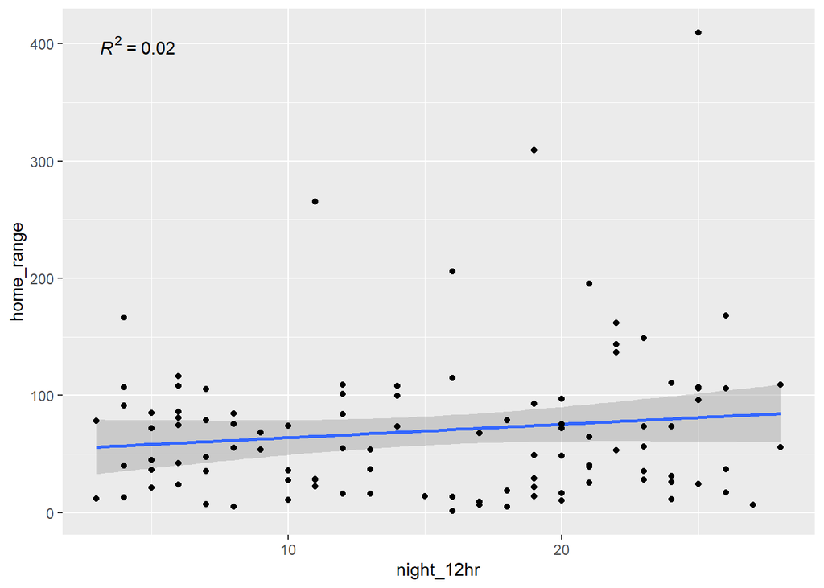

```r
ranges_res <- subset(ranges_data, cohort=="Resident")
ranges_fou <- subset(ranges_data, cohort=="Reinforcer")

ggplot(data = ranges_res, aes(night_12hr, home_range)) +
  stat_poly_line() + stat_poly_eq() + geom_point()
```

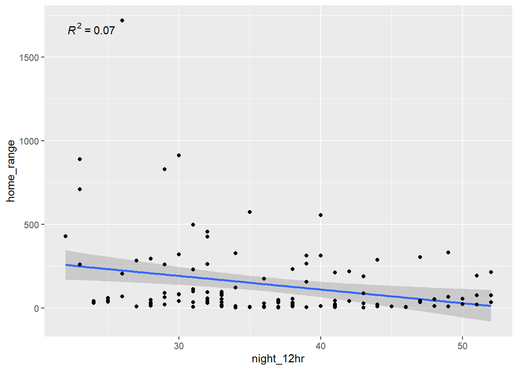

```r
ggplot(data = ranges_fou, aes(night_12hr, home_range)) +
  stat_poly_line() + stat_poly_eq() + geom_point()
```

We found residents exhibited relatively constant ranges (home range R2 = 0.02, core range R2 = 0.01), and reinforcers exhibited significantly negative trends in ranges (home and core ranges R2 = 0.07) over the study period.

**Summary statistics**

```r
res_ranges <- subset(ranges_model, cohort=="Resident")
fou_ranges <- subset(ranges_model, cohort=="Reinforcer")

ranges_model <- ranges_model %>%
  mutate(overall="Overall")

# Ranges overall
ranges_model %>%
  group_by(overall) %>%
  summarise(mean_hr=mean(home_range),
            se_hr=std.error(home_range),
            mean_cr=mean(core_range),
            se_cr=std.error(core_range))
```

```
## # A tibble: 1 × 5
##   overall mean_hr se_hr mean_cr se_cr
##   <chr>     <dbl> <dbl>   <dbl> <dbl>
## 1 Overall    178.  32.9    35.0  6.72
```

```r
# Ranges by cohort
ranges_model %>%
  group_by(cohort) %>%
  summarise(mean_hr=mean(home_range),
            se_hr=std.error(home_range),
            mean_cr=mean(core_range),
            se_cr=std.error(core_range))
```

```
## # A tibble: 2 × 5
##   cohort     mean_hr se_hr mean_cr se_cr
##   <fct>        <dbl> <dbl>   <dbl> <dbl>
## 1 Resident      89.9  11.5    19.9  2.45
## 2 Reinforcer   249.   53.2    47.3 11.2
```

```r
# Ranges by period
ranges_model %>%
  group_by(period) %>%
  summarise(mean_hr=mean(home_range),
            se_hr=std.error(home_range),
            mean_cr=mean(core_range),
            se_cr=std.error(core_range))
```

```
## # A tibble: 3 × 5
##   period     mean_hr se_hr mean_cr se_cr
##   <chr>        <dbl> <dbl>   <dbl> <dbl>
## 1 Baseline      83.1  9.95    19.4  2.71
## 2 Release      251.  58.4     48.0 12.1
## 3 Settlement   134.  43.0     26.1  9.62
```

On average, resident home ranges were 89.89 ha (±11.46) and core ranges were 19.93 ha (±2.45), and reinforcer home ranges were 249.39 ha (±53.16) and core ranges were 47.32 ha (±11.25).

## 5.2 Conspecific overlap

We also calculated the area of home and core range overlap (or static interaction) between dyads (pairs) of individuals using `st_intersection`.

### 5.2.1 Data curation

Compile range shapefiles

```r
lookup_distinct <- as.data.frame(lookup) %>%
  dplyr::select(-period, -fixes) %>%
  distinct(id=name, cohort, morph)

hr_lookup <- home_range %>%
  merge(lookup_distinct, by=c("id")) %>%
  mutate(cohort=ifelse(cohort=="Resident", "Residents", "Reinforcers")) %>%
  mutate(cohort=factor(cohort,
                       levels=c("Residents","Reinforcers")),
         range_type="Home range (95% KUD)")

cr_lookup <- core_range %>%
  merge(lookup_distinct, by=c("id")) %>%
  mutate(cohort=ifelse(cohort=="Resident", "Residents", "Reinforcers")) %>%
  mutate(cohort=factor(cohort,
                       levels=c("Residents","Reinforcers")),
         range_type="Core range (50% KUD)")

hr_cr_lookup <- rbind(hr_lookup, cr_lookup) %>%
    mutate(range_type=factor(range_type,
                             levels=c("Home range (95% KUD)",
                                      "Core range (50% KUD)")))
```

### 5.2.2 Maps

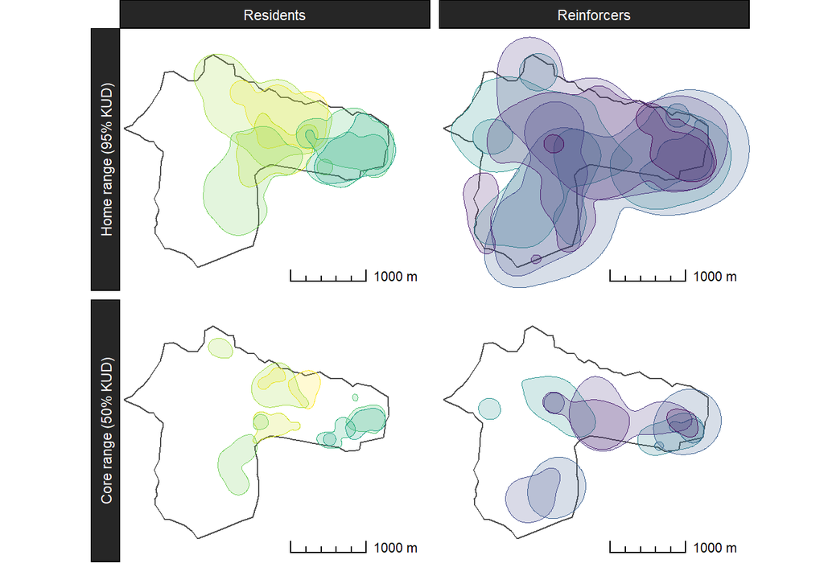

```r
# Map
hr_cr_map <- ggplot(hr_cr_lookup) +
  geom_path(mfws, mapping=aes(x=long, y=lat), col="grey30") +
  geom_sf(aes(fill=id, col=id), alpha=0.2) +
  coord_sf(xlim=c(695750, 699505), ylim=c(6104500, 6107675)) +
  annotation_scale(style="ticks", tick_height=0.5,
                   width_hint=0.3, pad_x=unit(3.7, "cm"),
                   pad_y=unit(0.2, "cm")) +
  theme(panel.grid.major = element_blank(),
        panel.grid.minor = element_blank(),
        panel.border = element_blank(),
        panel.background = element_rect(fill="white"),
        legend.position="none",
        axis.text.x = element_blank(),
        axis.text.y = element_blank(),
        axis.ticks.x = element_blank(),
        axis.ticks.y = element_blank(),
        plot.margin = unit(c(0, 0.2, 0, 0), "cm"),
        strip.background=element_rect(colour="black",
                                      fill="grey15"),
        strip.text=element_text(colour="white"),
        strip.text.y = element_text()) +
  scale_fill_viridis(discrete=T, option="D", begin=1, end=0) +
  scale_colour_viridis(discrete=T, option="D", begin=1, end=0) +
  facet_grid(range_type ~ cohort, switch = 'y') +
  xlab("") + ylab("")
print(hr_cr_map)
```

### 5.2.3 Calculate overlap

```r
# Home range overlap
list <- unique(home_range$id)
out <- data.frame()

for(i in 1:length(list)) {
  for (j in i+1:length(list)) {
  overlap <- st_intersection(filter(home_range, id==list[i]),
                        filter(home_range, id==list[j]))
  print(overlap)
  out <- rbind(out, overlap) }} #20 seconds

home_overlap <- out %>%
  mutate(area_int=as.numeric(st_area(.))*0.0001) %>%
  rename(name=id, name2=id.1, overlap=area_int) %>%
  dplyr::select(-area, -area.1)

# Core range overlap
list <- unique(core_range$id)
out <- data.frame()

for(i in 1:length(list)) {
  for (j in i+1:length(list)) {
  overlap <- st_intersection(filter(core_range, id==list[i]),
                        filter(core_range, id==list[j]))
  print(overlap)
  out <- rbind(out, overlap) }} #20 seconds

core_overlap <- out %>%
  mutate(area_int=as.numeric(st_area(.))*0.0001) %>%
  rename(name=id, name2=id.1, overlap=area_int) %>%
  dplyr::select(-area, -area.1)

# Extract areas and combine
overlap <- data.frame(left_join(st_drop_geometry(home_overlap),
                                st_drop_geometry(core_overlap),
                                by=c("name", "name2"))) %>%
  rename(home_overlap=overlap.x, core_overlap=overlap.y)

lookup_distinct2 <- lookup_distinct %>%
  # Lookup cohort of second quoll
  rename(name2=name, cohort2=cohort, morph2=morph)

overlap <- overlap %>%
  merge(lookup_distinct, by=c("name")) %>%
  merge(lookup_distinct2, by=c("name2")) %>%
  mutate(cohort=factor(cohort, levels=c("Resident","Reinforcer")))
overlap[is.na(overlap)] <- 0

write.csv(overlap, "output/overlap per individual.csv")
```

### 5.2.4 Models and summaries

```r
overlap <- read.csv("output/overlap per individual.csv") %>%
    mutate(cohort=factor(cohort, levels=c("Resident","Reinforcer")))

round(coef(summary(glm(home_overlap ~ cohort + morph,
                       data=overlap))), digits=5)
```

```
##                  Estimate Std. Error t value Pr(>|t|)
## (Intercept)      38.54369    8.42699 4.57384  0.00002
## cohortReinforcer 67.62228   11.60990 5.82453  0.00000
## morphFawn        13.65567   10.57833 1.29091  0.20008
```

```r
round(coef(summary(glm(core_overlap ~ cohort + morph,
                       data=overlap))), digits=5)
```

```
##                  Estimate Std. Error t value Pr(>|t|)
## (Intercept)       3.47243    1.18436 2.93189  0.00428
## cohortReinforcer  4.61578    1.63170 2.82881  0.00577
## morphFawn         0.68374    1.48672 0.45990  0.64671
```

We found significant differences between cohorts in the area of home (*p* < 0.0001) and core (*p* < 0.006) ranges that overlapped with those of other collared eastern quolls.

```r
res_overlap <- subset(overlap, cohort=="Resident") %>%
  na.omit()
fou_overlap <- subset(overlap, cohort=="Reinforcer") %>%
  na.omit()

# Summary statistics
data.frame(Cohort=c("Resident", "Resident", "Reinforcer", "Reinforcer"),
           Measure=rep(c("Home range (ha):", "Core range (ha):"), 2),
           Mean=c(mean(res_overlap$home_overlap),
                  mean(res_overlap$core_overlap),
                  mean(fou_overlap$home_overlap),
                  mean(fou_overlap$core_overlap)),
           SE=c(std.error(res_overlap$home_overlap),
                std.error(res_overlap$core_overlap),
                std.error(fou_overlap$home_overlap),
                std.error(fou_overlap$core_overlap)))
```

```
##       Cohort          Measure       Mean         SE
## 1   Resident Home range (ha):  45.992241  4.1504674
## 2   Resident Core range (ha):   3.845376  0.6485489
## 3 Reinforcer Home range (ha): 115.094682 15.2830804
## 4 Reinforcer Core range (ha):   8.535267  1.9933164
```

On average, resident home ranges overlapped by 45.99 ha (±4.15) and core ranges overlapped by 3.85 ha (±0.65), while reinforcer home ranges overlapped significantly more (by 115.09 ha, ±15.28), and core ranges overlapped by 8.54 ha (±1.99).

## 5.3 Plots

Finally, we plotted the significant differences in home range and home range overlap by cohort and study night.

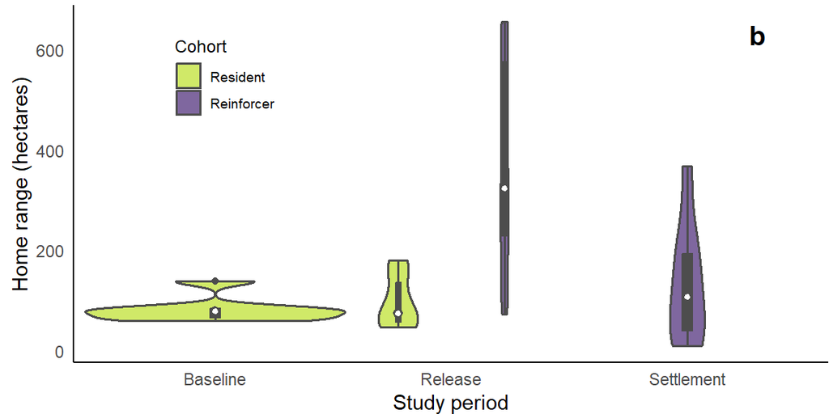

```r
# Set position dodge value for plotting
pos=position_dodge(0.9)

# Create boxplot
home_period <- ggplot(data=ranges_model,
                      aes(x=period, y=as.numeric(home_range))) +
  geom_violin(position=pos, aes(fill=cohort),
              col="grey30", alpha=0.7, width=1.1, lwd=0.6) +
  geom_boxplot(position=pos, aes(col=cohort),
               fill="grey30", width=0.04, lwd=0.6) +
  stat_summary(position=pos, aes(col=cohort),
               fun="median", geom="point",
               fill="white", shape=21, size=1.5, stroke=1) +
  annotate(geom="text", x=3.3, y=630, label="b", fontface="bold", size=5) +
  theme(panel.grid.major=element_blank(),
        panel.grid.minor=element_blank(),
        panel.background=element_rect(fill="white"),
        plot.margin=unit(c(0.1, 0, 0, 0.2), "cm"),
        axis.line=element_line(colour="black"),
        axis.ticks.x=element_blank(),
        axis.ticks.y=element_blank(),
        legend.position=c(0.2, 0.8),
        legend.title = element_text(size=9),
        legend.text = element_text(size=7),
        legend.key = element_rect(fill=NA),
        legend.key.height = unit(0.5, 'cm'),
        legend.key.width = unit(0.5, 'cm'),
        legend.background=element_blank()) +
  scale_colour_manual(values=c("grey30","grey30")) +
  scale_fill_manual(values=viridis(2, begin=0.9, end=0.1)) +
  xlab("Study period") + ylab("Home range (hectares)") +
  labs(fill="Cohort") + guides(colour="none")
print(home_period)
```

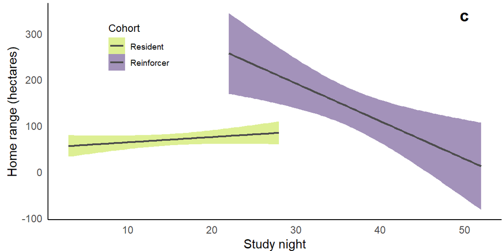

```r
# Regression plot
home_time <- ggplot(data=ranges_data, aes(x=night_12hr,
                                          y=as.numeric(home_range))) +
  geom_smooth(method='lm', aes(fill=cohort, col=cohort),
              lwd=0.8, alpha=0.5) +
  annotate(geom="text", x=50, y=340, label="c", fontface="bold", size=5) +
  theme(panel.grid.major=element_blank(),
        panel.grid.minor=element_blank(),
        panel.background=element_rect(fill="white"),
        plot.margin=unit(c(0.1, 0, 0, 0.2), "cm"),
        legend.position=c(0.2, 0.8),
        axis.line=element_line(colour="black"),
        axis.ticks.x=element_blank(),
        axis.ticks.y=element_blank(),
        strip.background=element_rect(colour="black", fill="grey30"),
        strip.text=element_text(colour="white"),
        legend.title = element_text(size=9),
        legend.text = element_text(size=7),
        legend.key = element_rect(fill = NA),
        legend.key.height = unit(0.5, 'cm'),
        legend.key.width = unit(0.5, 'cm'),
        legend.background=element_blank()) +
  scale_colour_manual(values=c("grey30","grey30")) +
  scale_fill_manual(values=viridis(2, begin=0.9, end=0.1)) +
  xlab("Study night") + ylab("Home range (hectares)") +
  labs(fill="Cohort", col="Cohort")
print(home_time)
```

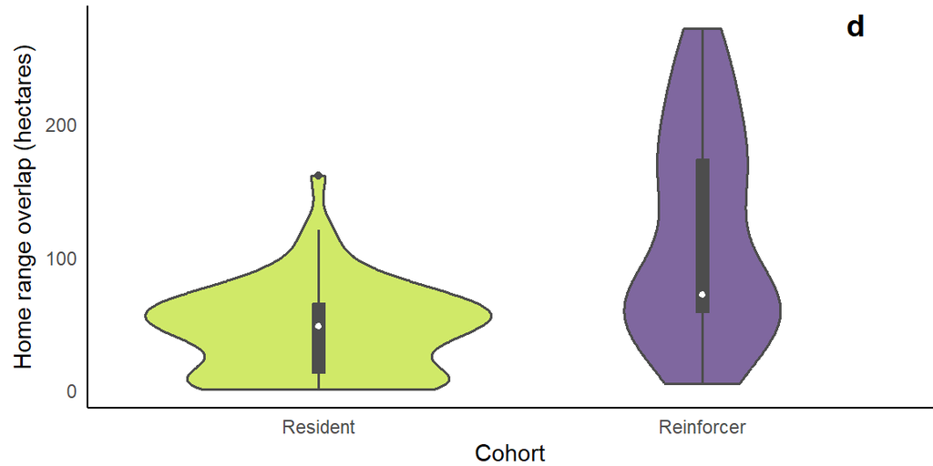

```r
# Boxplot
home_overlap_plot <- ggplot(overlap, aes(x=cohort,
                                         y=as.numeric(home_overlap))) +
  geom_violin(position=pos, aes(fill=cohort),
              col="grey30", alpha=0.7, lwd=0.6) +
  geom_boxplot(position=pos, aes(col=cohort),
               fill="grey30", width=0.03, lwd=0.6) +
  stat_summary(position=pos, aes(col=cohort),
               fun="median", geom="point",
               fill="white", shape=21, size=1.5, stroke=1) +
  annotate(geom="text", x=2.4, y=275, label="d", fontface="bold", size=5) +
  theme(panel.grid.major = element_blank(),
        panel.grid.minor = element_blank(),
        panel.background = element_rect(fill="white"),
        plot.margin = unit(c(0.1, 0, 0, 0.2), "cm"),
        legend.position = "none",
        axis.line = element_line(colour="black"),
        axis.ticks.x = element_blank(),
        axis.ticks.y = element_blank()) +
  scale_colour_manual(values=c("grey30","grey30")) +
  scale_fill_manual(values=viridis(2, begin=0.9, end=0.1)) +
  xlab("Cohort") + labs(fill="Cohort") +
  ylab(expression(paste("Home range overlap (hectares)")))
print(home_overlap_plot)
```

# 6 **Habitat use**

Here we investigated eastern quoll nocturnal activity (GPS fixes) and diurnal denning (VHF fixes), in terms of habitat type (NVIS polygons) and habitat attributes (LiDAR rasters).

Firstly, we used the [National Vegetation Information System (version 6.0)](http://www.environment.gov.au/fed/catalog/search/resource/details.page?uuid=%7Bab942d6d-9efd-4cf2-bec7-4c1521b83803%7D) major extant vegetation groups we created earlier (‘Clip by MFWS fence’ section) to create five broad habitat types relevant to MFWS. Below we visualised how the eight NVIS vegetation groups were aggregated into the five MFWS habitat types by **barplot** and **map**.

```r
nvis_shp <- readOGR(dsn="input/mfws_nvis_vegetation_groups.shp") %>%
  spTransform(CRS("+proj=longlat +ellps=WGS84 +datum=WGS84"))
```

```r
nvis_shp$area <- raster::area(nvis_shp)/1000000 #library(raster) in km2
fortify <- fortify(nvis_shp) #transforms from from sp to dataframe

nvis_groups <- aggregate(nvis_shp$area,
                         list(nvis_habitat=nvis_shp$MVG_NAME,
                              mfws_habitat=nvis_shp$MFWS_NAME), sum)

nvis_groups <- nvis_groups %>%
  mutate(area=x, perc=(area/4.839729)*100) %>%
  dplyr::select(-3) %>% na.omit() %>%
  mutate(nvis_habitat=factor(nvis_habitat,
                      levels=c("Eucalypt Woodlands",
                               "Eucalypt Open Woodlands",
                               "Regrowth, modified native vegetation",
                               "Tussock Grasslands",
                               "Eucalypt Open Forests",
                               "Eucalypt Tall Open Forests",
                               "Inland aquatic - freshwater, salt lakes, lagoons",
                               "Other Grasslands, Herblands, Sedgelands and Rushlands")),
         mfws_habitat=factor(mfws_habitat,
                      levels=c("Eucalypt woodland",
                               "Eucalypt forest",
                               "Regrowth", "Grassland",
                               "Aquatic"))) %>% arrange(-area)

# Barplot
nvis_barplot <- ggplot(nvis_groups, col="grey30",
                       aes(x=nvis_habitat, y=area, fill=mfws_habitat)) +
  geom_col(size=0.5, col="grey30", lwd=0.7, alpha=0.8) +
  geom_text(aes(label = paste0(round(perc, digits=1), "%"), vjust=-0.5)) +
  annotate(geom="text", x=8, y=2.1, label="a", fontface="bold", size=5) +
  theme(axis.line.x = element_line(colour="black"),
        axis.line.y = element_line(colour="black"),
        legend.position = "none",
        plot.margin = unit(c(0.2, 0.1, 0.1, 0.1), "cm"),
        panel.grid.major = element_blank(),
        panel.grid.minor = element_blank(),
        panel.background = element_blank(),
        panel.border = element_blank(),
        axis.ticks.x = element_blank(),
        axis.ticks.y = element_blank(),
        plot.title = element_text(hjust=0.5),
        text = element_text(colour="black"),
        axis.text.y = element_text(angle=0, vjust=0.5,
                                   hjust=0, color="black"),
        axis.text.x = element_text(angle=0, vjust=1,
                                   hjust=0.5, color="black")) +
  scale_fill_manual(values=viridis(5, begin=0.9, end=0.1)) +
  scale_x_discrete(labels=wrap_format(3)) + #library(scales)
  scale_y_continuous(limits=c(0,2.2)) +
  labs(fill="MFWS habitat") +
  xlab("NVIS major vegetation group") +
  ylab(expression(paste("Area (", km^2, ")")))
```

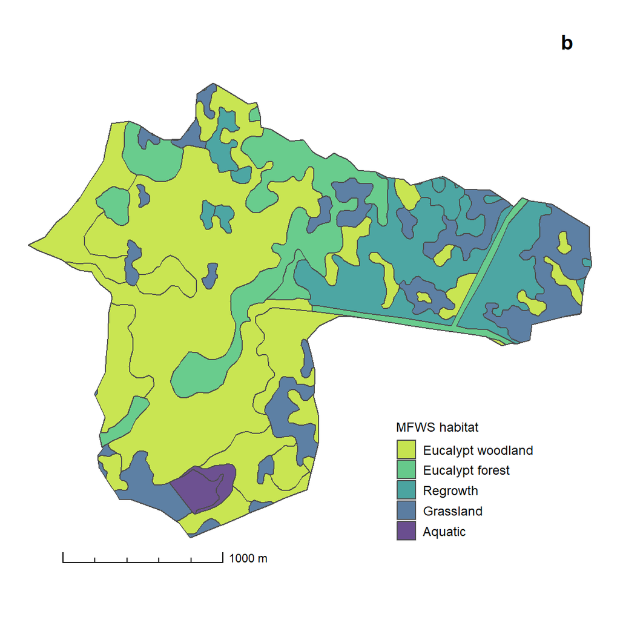

```r
# Map plot
nvis <- st_read("input/mfws_nvis_vegetation_groups.shp") %>%
  st_transform("EPSG:4326") %>%
  clean_names() %>%
  mutate(mfws_name=factor(mfws_name,
                          levels=c("Eucalypt woodland",
                                   "Eucalypt forest", "Regrowth",
                                   "Grassland", "Aquatic")))
nvis_mfws <- ggplot() +
  geom_sf(st_zm(nvis), mapping=aes(fill=mfws_name),
          col="grey30", lwd=0.5, alpha=0.8) +
  annotation_scale(style="ticks", tick_height=0.5,
                   width_hint=0.3,
                   pad_x=unit(1.55, "cm"),
                   pad_y=unit(0, "cm")) +
  annotate(geom="text", y=-35.154, x=149.185, label="b",
           fontface="bold", size=5) +
  theme(axis.line.x = element_blank(),
        axis.line.y = element_blank(),
        legend.position = c(0.75, 0.15),
        legend.title = element_text(size=9),
        legend.text = element_text(size=9),
        legend.key.size = unit(0.5, 'cm'),
        plot.margin = unit(c(0, 0, 1, 0), "cm"),
        panel.grid.major = element_blank(),
        panel.grid.minor = element_blank(),
        panel.background = element_blank(),
        panel.border = element_blank(),
        axis.ticks.x = element_blank(),
        axis.ticks.y = element_blank(),
        axis.ticks.length = unit(0, "pt"),
        plot.title = element_text(hjust=0.5),
        text = element_text(colour="black"),
        axis.text.y = element_blank(),
        axis.text.x = element_blank()) +
  scale_fill_manual(values=viridis(5, begin=0.9, end=0.1)) +
  labs(fill="MFWS habitat", x=NULL, y=NULL)
print(nvis_mfws)
```

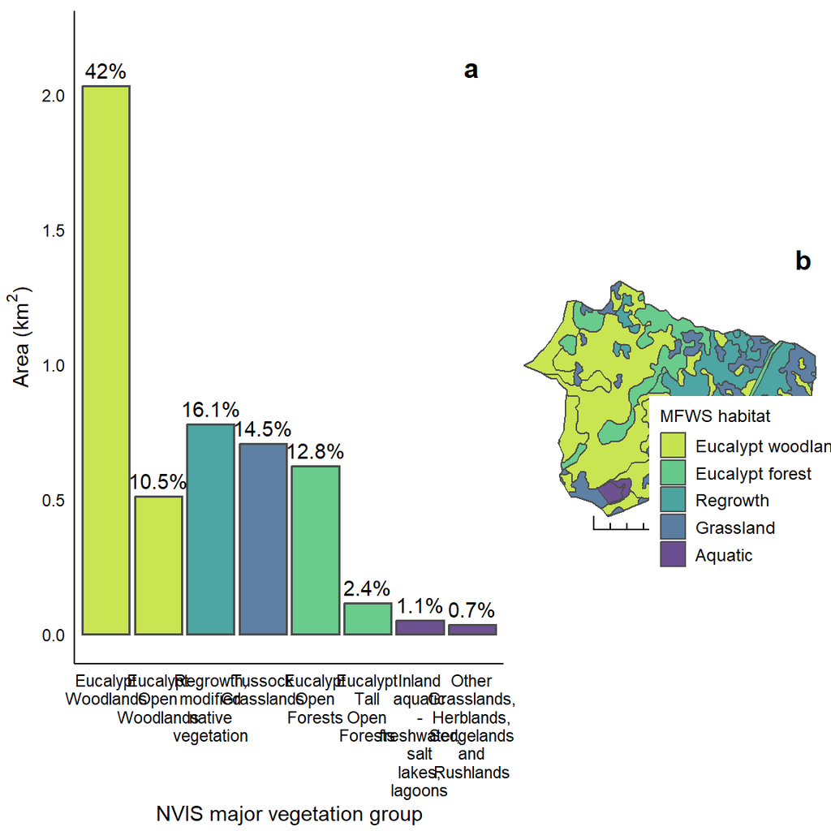

```r
nvis_methods <- ggarrange(nvis_barplot, nvis_mfws,
                          ncol=2, nrow=1, widths=c(4.75, 3))
print(nvis_methods)
```

## 6.1 Nocturnal activity

### 6.1.1 Habitat type

Here we calculate the frequency of nocturnal locations (GPS fixes) per habitat type, adjusting these for habitat availability (area).

```r
#data for plots
noc <- read.csv("output/coordinates curated.csv") %>%
  group_by(mfws_habitat) %>%
  count() %>%
  # Create frequency and percentage (adjusted by frequency of fixes) variables
  mutate(freq=n, perc=(freq/2950)*100)

mfws_group <- as.data.frame(nvis_shp) %>%
  clean_names() %>%
  mutate(mfws_habitat=mfws_name) %>%
  group_by(mfws_habitat) %>%
  summarise(area=sum(area))

noc_plot <- noc %>% clean_names() %>%
  left_join(mfws_group, by="mfws_habitat") %>%
  # Adjust frequency by total area
  mutate(freq_adj=freq/area,
         # Adjust percentage by total frequencies
         perc_adj=(freq_adj/2343.5) *100,
         mfws_habitat=factor(mfws_habitat,
                             levels=c("Eucalypt woodland",
                                      "Eucalypt forest",
                                      "Regrowth", "Grassland",
                                      "Aquatic")),
         type="Nocturnal activity")

# Read in coordinates for modelling
noc_period <- read.csv("output/coordinates curated.csv") %>%
  group_by(cohort, period, morph, name, mfws_habitat) %>%
  summarise(fixes=length(mfws_habitat))

noc_total <- noc_period %>%
  group_by(cohort, period, morph, name) %>%
  summarise(total=sum(fixes))

noc_model <- left_join(noc_period, noc_total) %>%
  mutate(percentage=(100/total)*fixes) %>%
  mutate(mfws_habitat=factor(mfws_habitat,
                             levels=c("Eucalypt woodland",
                                      "Eucalypt forest",
                                      "Regrowth", "Grassland",
                                      "Aquatic")))
```

### 6.1.2 Habitat attributes

We also quantified eastern quoll habitat use using the following LiDAR rasters:

1. [Overstory layer cover fraction (LCF_OS)](https://dapds00.nci.org.au/thredds/catalog/ub8/au/TERN/lidar/ACT/5m/LCF_OS/catalog.html),
2. [Understory layer cover fraction (LCF_US)](https://dapds00.nci.org.au/thredds/catalog/ub8/au/TERN/lidar/ACT/5m/LCF_US/catalog.html), and
3. [Derived aspect (from DEM)](https://dapds00.nci.org.au/thredds/catalog/ub8/au/TERN/lidar/ACT/5m/DEM/catalog.html).

```r
# Install and load required packages
pacman::p_load(ggpubr, lme4, MuMIn, plotrix, raster, sf, viridis)

# Read in raster data
overstory <- raster("input/mfgo_overstory.tif")
understory <- raster("input/mfgo_understory.tif")
aspect <- raster("input/mfgo_aspect.tif")

# Read in coordinates data
noc <- read.csv("output/coordinates curated.csv") %>%
  mutate(easting=as.numeric(easting),
         northing=as.numeric(northing))

# Convert and project coordinates as spatial points using sp
noc_sp <- SpatialPointsDataFrame(
    data.frame(noc$easting, noc$northing), noc,
    proj4string=CRS("EPSG:32755")) %>%
  st_as_sf()

# Extract raster values for each coordinate
noc_lidar <- noc_sp %>%
  mutate(overstory=raster::extract(overstory, noc_sp, method="simple"),
         understory=raster::extract(understory, noc_sp, method="simple"),
         aspect=raster::extract(aspect, noc_sp, method="simple"),
         date=as.POSIXct(date),
         # Create day of the year (1-365) variable
         day=as.numeric(yday(date))) %>%
  na.omit() %>%
  st_drop_geometry()
```

To determine whether the overstory, understory, and aspect values for each individual’s location is related to availability or preference, we need to compare them with the available values in Mulligans Flat.

```r
# Read in MFWS fence polygon using sf
mf_fence <- st_read("input/mfws_fence.shp", quiet=TRUE) %>%
  st_set_crs("EPSG:32755")

# Extract available overstory in MFWS
overstory_mf <- as.data.frame(rasterToPoints(mask(overstory, mf_fence))) %>%
  mutate(type="Available", raster="Overstory",
         raster_units=mfgo_overstory*100) %>%
  dplyr::select(type, raster, raster_units)

# Extract available understory in MFWS
understory_mf <- as.data.frame(rasterToPoints(mask(understory, mf_fence))) %>%
  mutate(type="Available", raster="Understory",
         raster_units=mfgo_understory*100) %>%
  dplyr::select(type, raster, raster_units)

# Extract available aspects in MFWS
aspect_mf <- as.data.frame(rasterToPoints(mask(aspect, mf_fence))) %>%
  mutate(type="Available", raster="Aspect",
         raster_units=mfgo_aspect) %>%
  dplyr::select(type, raster, raster_units)

# Combine raster values into single df
raster_mf <- rbind(overstory_mf, understory_mf, aspect_mf) %>%
  dplyr::select(type, raster, raster_units)
```

### 6.1.3 Models and summaries

#### 6.1.3.1 Habitat types

Here we tested for habitat preference in nocturnal activity compared to a random distribution using the Chi-square test for given probabilities, using frequencies of locations in each habitat with the proportional area of each habitat available in MFWS.

We found the distribution of eastern quoll locations in each habitat type varied significantly from random distribution (χ2 = 1455.8, df = 3, *p* < 2.2e-16).

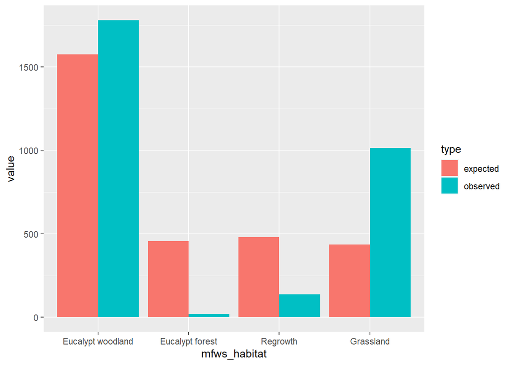

```r
noc_use <- noc_plot %>%
  dplyr::select(mfws_habitat, freq, area) %>%
  mutate(observed=freq,
         # Create proportion of MFWS minus aquatic habitat
         proportion=area/sum(noc_plot$area),
         expected=proportion*sum(noc_plot$freq)) %>%
  dplyr::select(-freq)

plotdat <- gather(noc_use, type, value, observed, expected)

# Plot MFWS habitat types
chi_plot <- ggplot(plotdat, aes(mfws_habitat, value, fill=type)) +
  geom_bar(stat="identity", position='dodge')
chi_plot
```

```r
chisq.test(noc_use$observed, p=noc_use$proportion, correct=TRUE)
```

```
##
##  Chi-squared test for given probabilities
##
## data:  noc_use$observed
## X-squared = 1455.8, df = 3, p-value < 2.2e-16
```

Next we use GLMMs to test the fixed effects of `cohort`, `period`, and `morph` on the percentage of fixes spent in woodland, forest, regrowth, or grassland aftering adjusting for habitat availability.

```r
woodland <- subset(noc_model, mfws_habitat=="Eucalypt woodland")
round(coef(summary(lmer(percentage ~ cohort*period + morph +
                          (1|name), data=woodland))), digits=4)
```

```
##                  Estimate Std. Error t value
## (Intercept)       53.6746    13.0437  4.1150
## cohortResident     2.0448    12.2016  0.1676
## periodRelease      3.3319     7.1449  0.4663
## periodSettlement  -1.3169     9.4931 -0.1387
## morphFawn          3.2447    11.2636  0.2881
```

```r
forest <- subset(noc_model, mfws_habitat=="Eucalypt forest")
round(coef(summary(lmer(percentage ~ cohort*period + morph +
                          (1|name), data=forest))), digits=4)
```

```
##                  Estimate Std. Error t value
## (Intercept)        4.6683     1.2979  3.5969
## cohortResident    -4.1922     1.8152 -2.3095
## periodSettlement   0.8872     0.2722  3.2599
## morphFawn         -2.3948     1.4820 -1.6159
```

```r
regrowth <- subset(noc_model, mfws_habitat=="Regrowth")
round(coef(summary(lmer(percentage ~ cohort*period + morph +
                          (1|name), data=regrowth))), digits=4)
```

```
##                  Estimate Std. Error t value
## (Intercept)        7.6453     8.1618  0.9367
## cohortResident    -1.5287     8.4674 -0.1805
## periodRelease     -0.0470     2.5288 -0.0186
## periodSettlement  -4.8040     4.2419 -1.1325
## morphFawn          4.9129     8.0736  0.6085
```

```r
grassland <- subset(noc_model, mfws_habitat=="Grassland")
round(coef(summary(lmer(percentage ~ cohort*period + morph +
                          (1|name), data=grassland))), digits=4)
```

```
##                  Estimate Std. Error t value
## (Intercept)       38.4142    13.9262  2.7584
## cohortResident     2.4940    12.2328  0.2039
## periodRelease     -1.7253     8.9458 -0.1929
## periodSettlement   8.9125    11.9188  0.7478
## morphFawn         -5.9161    10.6026 -0.5580
```

#### 6.1.3.2 **Habitat attributes**

Next, we used GLMMs to test the fixed effects of `cohort`, `period`, and `morph` on the habitat attributes (i.e., `overstory`, `understory`, and `aspect`) of nocturnal locations.

⚠️🚩

```r
mod <- lmer(overstory ~ cohort*period + morph +
              (1|name), data=noc_lidar)
anova(mod) #F-statistic
```

```
## Analysis of Variance Table
##        npar    Sum Sq    Mean Sq F value
## cohort    1 0.0006220 0.00062200  0.0306
## period    2 0.0038148 0.00190738  0.0938
## morph     1 0.0000917 0.00009172  0.0045
```

```r
car::Anova(mod) #Chisq, p-value
```

```
## Analysis of Deviance Table (Type II Wald chisquare tests)
##
## Response: overstory
##                Chisq Df Pr(>Chisq)
## cohort        0.0009  1     0.9767
## period        0.1888  2     0.9099
## morph         0.0045  1     0.9465
## cohort:period         0
```

```r
summary(mod) #t-statistic, random effects
```

```
## Linear mixed model fit by REML ['lmerMod']
## Formula: overstory ~ cohort * period + morph + (1 | name)
##    Data: noc_lidar
##
## REML criterion at convergence: -3048.6
##
## Scaled residuals:
##     Min      1Q  Median      3Q     Max
## -1.4126 -0.6975 -0.4036  0.6037  3.7456
##
## Random effects:
##  Groups   Name        Variance Std.Dev.
##  name     (Intercept) 0.001446 0.03803
##  Residual             0.020341 0.14262
## Number of obs: 2949, groups:  name, 15
##
## Fixed effects:
##                    Estimate Std. Error t value
## (Intercept)       0.1171882  0.0218855   5.355
## cohortResident   -0.0006499  0.0222372  -0.029
## periodRelease     0.0037674  0.0086798   0.434
## periodSettlement  0.0036059  0.0121268   0.297
## morphFawn         0.0014042  0.0209124   0.067
##
## Correlation of Fixed Effects:
##             (Intr) chrtRs prdRls prdStt
## cohortRsdnt -0.622
## periodReles -0.410  0.306
## perdSttlmnt -0.459  0.386  0.716
## morphFawn   -0.610  0.062  0.022  0.008
## fit warnings:
## fixed-effect model matrix is rank deficient so dropping 2 columns / coefficients
```

```r
mod <- lmer(understory ~ cohort*period + morph +
              (1|name), data=noc_lidar)
anova(mod) #F-statistic
```

```
## Analysis of Variance Table
##        npar    Sum Sq   Mean Sq F value
## cohort    1 0.0007578 0.0007578  0.8553
## period    2 0.0243201 0.0121601 13.7244
## morph     1 0.0002132 0.0002132  0.2406
```

```r
car::Anova(mod) #Chisq, p-value
```

```
## Analysis of Deviance Table (Type II Wald chisquare tests)
##
## Response: understory
##                 Chisq Df Pr(>Chisq)
## cohort         4.9397  1    0.02625 *
## period        27.6094  2  1.011e-06 ***
## morph          0.2406  1    0.62379
## cohort:period          0
## ---
## Signif. codes:  0 '***' 0.001 '**' 0.01 '*' 0.05 '.' 0.1 ' ' 1
```

```r
summary(mod) #t-statistic, random effects
```

```
## Linear mixed model fit by REML ['lmerMod']
## Formula: understory ~ cohort * period + morph + (1 | name)
##    Data: noc_lidar
##
## REML criterion at convergence: -12284.5
##
## Scaled residuals:
##     Min      1Q  Median      3Q     Max
## -1.1031 -0.6106 -0.3056  0.2796  9.5367
##
## Random effects:
##  Groups   Name        Variance  Std.Dev.
##  name     (Intercept) 2.346e-05 0.004843
##  Residual             8.860e-04 0.029766
## Number of obs: 2949, groups:  name, 15
##
## Fixed effects:
##                  Estimate Std. Error t value
## (Intercept)      0.012765   0.003402   3.752
## cohortResident   0.007325   0.003296   2.223
## periodRelease    0.008799   0.001803   4.881
## periodSettlement 0.005374   0.002517   2.136
## morphFawn        0.001389   0.002832   0.490
##
## Correlation of Fixed Effects:
##             (Intr) chrtRs prdRls prdStt
## cohortRsdnt -0.698
## periodReles -0.549  0.427
## perdSttlmnt -0.614  0.540  0.716
## morphFawn   -0.547  0.072  0.035  0.013
## fit warnings:
## fixed-effect model matrix is rank deficient so dropping 2 columns / coefficients
```

```r
mod <- lmer(aspect ~ cohort*period + morph +
              (1|name), data=noc_lidar)
anova(mod) #F-statistic
```

```
## Analysis of Variance Table
##        npar Sum Sq Mean Sq F value
## cohort    1   3299    3299  0.9377
## period    2  64120   32060  9.1129
## morph     1    863     863  0.2452
```

```r
car::Anova(mod) #Chisq, p-value
```

```
## Analysis of Deviance Table (Type II Wald chisquare tests)
##
## Response: aspect
##                 Chisq Df Pr(>Chisq)
## cohort         0.2463  1  0.6197110
## period        18.2025  2  0.0001115 ***
## morph          0.2452  1  0.6204431
## cohort:period          0
## ---
## Signif. codes:  0 '***' 0.001 '**' 0.01 '*' 0.05 '.' 0.1 ' ' 1
```

```r
summary(mod) #t-statistic, random effects
```

```
## Linear mixed model fit by REML ['lmerMod']
## Formula: aspect ~ cohort * period + morph + (1 | name)
##    Data: noc_lidar
##
## REML criterion at convergence: 32479.2
##
## Scaled residuals:
##     Min      1Q  Median      3Q     Max
## -3.9934 -0.6464 -0.0591  0.6144  3.3434
##
## Random effects:
##  Groups   Name        Variance Std.Dev.
##  name     (Intercept) 1512     38.89
##  Residual             3518     59.31
## Number of obs: 2949, groups:  name, 15
##
## Fixed effects:
##                  Estimate Std. Error t value
## (Intercept)      203.0917    19.4435  10.445
## cohortResident   -10.2272    20.6085  -0.496
## periodRelease     -0.8251     3.6199  -0.228
## periodSettlement  14.2406     5.0604   2.814
## morphFawn         10.2367    20.6710   0.495
##
## Correlation of Fixed Effects:
##             (Intr) chrtRs prdRls prdStt
## cohortRsdnt -0.554
## periodReles -0.192  0.138
## perdSttlmnt -0.215  0.174  0.715
## morphFawn   -0.667  0.056  0.009  0.003
## fit warnings:
## fixed-effect model matrix is rank deficient so dropping 2 columns / coefficients
```

**Summary statistics**

```r
# Overall
data.frame(Measure=c("Overstory (%):",
                     "Understory (%):",
                     "Aspect (°):"),
           Mean=c(mean(noc_lidar$overstory)*100,
                  mean(noc_lidar$understory)*100,
                  mean(noc_lidar$aspect)),
           SE=c(std.error(noc_lidar$overstory)*100,
                std.error(noc_lidar$understory)*100,
                std.error(noc_lidar$aspect)))
```

```
##           Measure       Mean         SE
## 1  Overstory (%):  12.650685 0.27076825
## 2 Understory (%):   2.232583 0.05555441
## 3     Aspect (°): 202.980737 1.27387115
```

```r
# Understory per period
noc_lidar %>%
  group_by(period) %>%
  summarise(mean=mean(understory*100),
            se=std.error(understory*100))
```

```
## # A tibble: 3 × 3
##   period      mean     se
##   <chr>      <dbl>  <dbl>
## 1 Baseline    2.07 0.0807
## 2 Release     2.57 0.115
## 3 Settlement  2.10 0.0948
```

```r
# Aspect per period
noc_lidar %>%
  group_by(period) %>%
  summarise(mean=mean(aspect),
            se=std.error(aspect))
```

```
## # A tibble: 3 × 3
##   period      mean    se
##   <chr>      <dbl> <dbl>
## 1 Baseline    195.  1.91
## 2 Release     194.  2.29
## 3 Settlement  222.  2.38
```

On average, eastern quolls were active in areas with an `overstory` of 12.65% (layer cover, ±0.27), `understory` of 2.23 (layer cover, ±0.06), and `aspect` of 202.98° (±1.27, i.e., south-southwest-facing).

## 6.2 Diurnal denning

Similarly, we calculated the frequency of diurnal dens (VHF fixes) per habitat type, and adjusted the frequency for area of habitat available.

### 6.2.1 Habitat types

```r
# Read in coordinates data and prepare for plotting
diu <- read_excel(raw_data, sheet="dens") %>%
  clean_names() %>%
  na.omit() %>%
  mutate(easting=as.numeric(easting),
         northing=as.numeric(northing),
         date=as.POSIXct(date_tracked),
         day=as.numeric(yday(date)), #day of the year variable
         night=(as.numeric(yday(date)) - 157), #night variable)
         period=ifelse(night >=3 & night <=21, 'Baseline',
                ifelse(night >=22 & night <=32, 'Release',
                ifelse(night >=33 & night <=52, 'Settlement', NA)))) %>%
  # Remove irrelevant dates
  subset(night >=3 & night <=52) %>%
  subset(ifelse(cohort=="Resident", night <=32, night >=22))

diu_sp <- SpatialPointsDataFrame( #library(sp)
  data.frame(diu$easting, diu$northing), diu,
  proj4string=CRS("EPSG:32755")) %>% st_as_sf()

nvis <- st_read("input/mfws_nvis_vegetation_groups.shp", quiet=TRUE) %>%
  st_transform("EPSG:32755")

diu_nvis <- st_join(diu_sp, nvis, join=st_intersects) %>%
  rename(mfws_habitat=MFWS_NAME) %>%
  st_drop_geometry()

diu_adj <- diu_nvis %>%
  group_by(mfws_habitat) %>% count() %>%
  mutate(freq=n, perc=(freq/413)*100) #adjusted by frequency of dens

diu_plot <- diu_adj %>% clean_names() %>%
  left_join(mfws_group, by="mfws_habitat") %>%
  mutate(freq_adj=freq/area, #adjusted by total area
         perc_adj=(freq_adj/383.1) *100, #adjusted by total freq_adj
         mfws_habitat=factor(mfws_habitat,
                             levels=c("Eucalypt woodland",
                                      "Eucalypt forest",
                                      "Regrowth", "Grassland",
                                      "Aquatic")))
#data for modelling
diu_period <- diu_nvis %>%
  group_by(cohort, period, morph, name, mfws_habitat) %>%
  summarise(dens=length(mfws_habitat))

diu_total <- diu_period %>%
  group_by(cohort, period, morph, name) %>%
  summarise(total=sum(dens))

diu_model <- left_join(diu_period, diu_total) %>%
  mutate(percentage=(100/total)*dens,
         mfws_habitat=factor(mfws_habitat,
                             levels=c("Eucalypt woodland",
                                      "Eucalypt forest",
                                      "Regrowth", "Grassland",
                                      "Aquatic")))
```

### 6.2.2 Habitat attributes

```r
diu <- read_excel(raw_data, sheet="dens") %>%
  clean_names() %>%
  na.omit() %>%
  mutate(easting = as.numeric(easting),
         northing = as.numeric(northing),
         date = as.POSIXct(date_tracked),
         # Day of the year variable
         day = as.numeric(yday(date)),
         # Night variable
         night = (as.numeric(yday(date)) - 157),
         period = ifelse(night >=3 & night <=21, 'Baseline',
                  ifelse(night >=22 & night <=32, 'Release',
                  ifelse(night >=33 & night <=52, 'Settlement', NA)))) %>%
  # Remove irrelevant dates
  subset(night >=3 & night <=52) %>%
  subset(ifelse(cohort=="Resident", night <=32, night >=22))

diu_sp <- SpatialPointsDataFrame(
  data.frame(diu$easting, diu$northing), diu,
  proj4string=CRS("EPSG:32755")) %>%
  st_as_sf()

diu_lidar <- diu_sp %>%
  mutate(overstory=raster::extract(overstory, diu_sp, method="simple"),
         understory=raster::extract(understory, diu_sp, method="simple"),
         aspect=raster::extract(aspect, diu_sp, method="simple")) %>%
  na.omit() %>%
  st_drop_geometry()
```

### 6.2.3 Models and summaries

Here we tested for habitat preference in diurnal denning compared to a random distribution using the Chi-square test for given probabilities, using frequencies of dens in each habitat with the proportional area of each habitat available in MFWS.

We found the distribution of eastern quoll dens in each habitat type varied significantly from random distribution (χ2 = 45.629, df = 3, *p* < 6.8e-10).

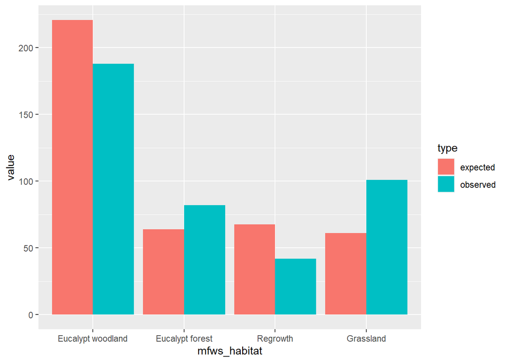

```r
diu_use <- diu_plot %>%
  dplyr::select(mfws_habitat, freq, area) %>%
  mutate(observed=freq,
         proportion=area/sum(diu_plot$area), #area of MFWS minus aquatic habitat
         expected=proportion*sum(diu_plot$freq)) %>%
  dplyr::select(-freq)

plotdat <- gather(diu_use, type, value, observed, expected)
chi_plot <- ggplot(plotdat, aes(mfws_habitat, value, fill=type)) +
  geom_bar(stat="identity", position='dodge')
chi_plot
```

```r
chisq.test(diu_use$observed, p=diu_use$proportion, correct=TRUE)
```

```
##
##  Chi-squared test for given probabilities
##
## data:  diu_use$observed
## X-squared = 45.629, df = 3, p-value = 6.8e-10
```

Next we use GLMMs to test the fixed effects of `cohort`, `period`, and `morph` on the percentage of fixes spent in woodland, forest, regrowth, or grassland. We found no significant differences driven by `cohort`, `period`, or `morph` on the percentage of diurnal dens in each habitat type.

After accounting for habitat availability, eastern quolls denned preferring to den in grassland (37.45%), Eucalypt forest (29.14%), Eucalypt woodland (19.32%), and regrowth (14.11%).

```r
woodland <- subset(diu_model, mfws_habitat=="Eucalypt woodland")
round(coef(summary(lmer(percentage ~ cohort*period + morph +
                          (1|name), data=woodland))), digits=4)
```

```
##                  Estimate Std. Error t value
## (Intercept)       45.8549    24.3144  1.8859
## cohortResident     4.7401    20.5602  0.2305
## periodRelease     14.4523    15.4624  0.9347
## periodSettlement  10.1091    23.0169  0.4392
## morphFawn          4.0243    17.7686  0.2265
```

```r
forest <- subset(diu_model, mfws_habitat=="Eucalypt forest")
round(coef(summary(lmer(percentage ~ cohort*period + morph +
                          (1|name), data=forest))), digits=4)
```

```
##                  Estimate Std. Error t value
## (Intercept)       15.3406    18.2004  0.8429
## cohortResident     9.2743    13.9089  0.6668
## periodRelease     17.8078    12.4752  1.4275
## periodSettlement   9.7079    19.3516  0.5017
## morphFawn         -1.0568     9.7246 -0.1087
```

```r
regrowth <- subset(diu_model, mfws_habitat=="Regrowth")
round(coef(summary(lmer(percentage ~ cohort*period + morph +
                          (1|name), data=regrowth))), digits=4)
```

```
##                  Estimate Std. Error t value
## (Intercept)       46.7324    15.2714  3.0601
## cohortResident   -23.1860    15.5619 -1.4899
## periodRelease     -4.8238    12.7157 -0.3794
## periodSettlement -22.5549    18.5886 -1.2134
## morphFawn         -1.3326    10.8411 -0.1229
```

```r
grassland <- subset(diu_model, mfws_habitat=="Grassland")
round(coef(summary(lmer(percentage ~ cohort*period + morph +
                          (1|name), data=grassland))), digits=4)
```

```
##                  Estimate Std. Error t value
## (Intercept)       32.0666    18.9797  1.6895
## cohortResident    -1.4567    15.9274 -0.0915
## periodRelease     -8.3818    15.2763 -0.5487
## periodSettlement  16.0057    21.8211  0.7335
## morphFawn          5.7457    11.8403  0.4853
```

Next, we used GLMMs to test the fixed effects of `cohort`, `period`, and `morph` on the habitat attributes (i.e., `overstory`, `understory`, and `aspect`) of diurnal dens.

```r
round(coef(summary(lmer(overstory ~ cohort*period + morph +
                          (1|name), data=diu_lidar))), digits=4)
```

```
##                  Estimate Std. Error t value
## (Intercept)        0.1657     0.0706  2.3474
## cohortResident     0.1124     0.0723  1.5537
## periodRelease      0.0313     0.0163  1.9233
## periodSettlement   0.0609     0.0249  2.4456
## morphFawn         -0.0672     0.0727 -0.9244
```

```r
round(coef(summary(lmer(understory ~ cohort*period + morph +
                          (1|name), data=diu_lidar))), digits=4)
```

```
##                  Estimate Std. Error t value
## (Intercept)        0.0184     0.0087  2.1142
## cohortResident     0.0159     0.0086  1.8451
## periodRelease      0.0044     0.0033  1.3482
## periodSettlement   0.0101     0.0050  1.9972
## morphFawn         -0.0084     0.0082 -1.0279
```

```r
round(coef(summary(lmer(aspect ~ cohort*period + morph +
                          (1|name), data=diu_lidar))), digits=4)
```

```
##                  Estimate Std. Error t value
## (Intercept)      209.6783    13.0036 16.1246
## cohortResident   -17.0750    12.4831 -1.3679
## periodRelease    -10.7982     6.1498 -1.7559
## periodSettlement   1.9053     9.3616  0.2035
## morphFawn         15.9355    11.1437  1.4300
```

**Summary statistics**

```r
# Overall
data.frame(Measure=c("Overstory (%):",
                     "Understory (%):",
                     "Aspect (°):"),
           Mean=c(mean(diu_lidar$overstory)*100,
                  mean(diu_lidar$understory)*100,
                  mean(diu_lidar$aspect)),
           SE=c(std.error(diu_lidar$overstory)*100,
                std.error(diu_lidar$understory)*100,
                std.error(diu_lidar$aspect)))
```

```
##           Measure       Mean        SE
## 1  Overstory (%):  20.882876 0.8865039
## 2 Understory (%):   2.600128 0.1382388
## 3     Aspect (°): 207.271022 2.4113036
```

```r
# Overstory per period
diu_lidar %>%
  group_by(period) %>%
  summarise(mean=mean(overstory*100),
            se=std.error(overstory*100))
```

```
## # A tibble: 3 × 3
##   period      mean    se
##   <chr>      <dbl> <dbl>
## 1 Baseline    23.8  1.56
## 2 Release     21.2  1.48
## 3 Settlement  17.2  1.51
```

```r
# Aspect per period
diu_lidar %>%
  group_by(period) %>%
  summarise(mean=mean(aspect),
            se=std.error(aspect))
```

```
## # A tibble: 3 × 3
##   period      mean    se
##   <chr>      <dbl> <dbl>
## 1 Baseline    202.  3.47
## 2 Release     199.  4.20
## 3 Settlement  222.  4.68
```

On average, eastern quolls denned in areas with an overstory of 20.88% (layer cover, ±0.89), understory of 2.60 (layer cover, ±0.14), and aspect of 207.27° (±2.41, i.e., south-southwest-facing).

## 6.3 Comparison

Here we combine the nocturnal activity and diurnal den locations into a single dataframe.

```r
noc_lidar_plot <- noc_lidar %>%
  mutate('Overstory'=overstory*100, 'Understory'=understory*100,
         'Aspect'=aspect) %>%
  gather(raster, raster_units,
         'Overstory':'Aspect', factor_key=TRUE) %>%
  mutate(cohort=factor(cohort, levels=c("Resident", "Reinforcer")),
         raster=factor(raster, levels=c("Overstory", "Understory", "Aspect")),
         type="Nocturnal activity") %>%
  dplyr::select(quoll, cohort, period, morph,
                day, raster, raster_units, type)

diu_lidar_plot <- diu_lidar %>%
  mutate('Overstory'=overstory*100,  'Understory'=understory*100,
         'Aspect'=aspect) %>%
  gather(raster, raster_units,
         'Overstory':'Aspect', factor_key=TRUE) %>%
  mutate(cohort=factor(cohort, levels=c("Resident", "Reinforcer")),
         raster=factor(raster, levels=c("Overstory", "Understory", "Aspect")),
         type="Diurnal denning") %>%
  dplyr::select(quoll, cohort, period, morph,
                day, raster, raster_units, type)

lidar_plot <- rbind(noc_lidar_plot, diu_lidar_plot) %>%
  mutate(type=factor(type, levels=c("Nocturnal activity",
                                    "Diurnal denning"))) %>%
  dplyr::select("type", "raster", "raster_units") %>%
  rbind(raster_mf)
```

```r
avai_lidar <- subset(lidar_plot, type=="Available")
avai_os <- subset(avai_lidar, raster=="Overstory")
avai_us <- subset(avai_lidar, raster=="Understory")
avai_as <- subset(avai_lidar, raster=="Aspect")

# Summary statistics
data.frame(Measure=c("Overstory (%):", "Understory (%):",
                     "Aspect (°):"),
           Mean=c(mean(avai_os$raster_units),
                  mean(avai_us$raster_units),
                  mean(avai_as$raster_units)),
           SE=c(std.error(avai_os$raster_units),
                std.error(avai_us$raster_units),
                std.error(avai_as$raster_units)))
```

```
##           Measure       Mean          SE
## 1  Overstory (%):  13.686374 0.023198655
## 2 Understory (%):   1.895716 0.003946811
## 3     Aspect (°): 205.121520 0.114173331
```

Across the sanctuary, there was average overstory layer cover of 13.69% (±0.02), understory of 1.90% (±0.0.004), and aspect of 205.12° (±0.11, i.e., south-southwest-facing) available.

### 6.3.1 Models

```r
lidar_os <- subset(lidar_plot, raster=="Overstory")
lidar_us <- subset(lidar_plot, raster=="Understory")
lidar_as <- subset(lidar_plot, raster=="Aspect")

round(coef(summary(glm(raster_units ~ type,
                       data=lidar_os))), digits=5)
```

```
##                     Estimate Std. Error  t value Pr(>|t|)
## (Intercept)         12.65068    0.28295 44.70956  0.00000
## typeDiurnal denning  8.23219    0.80730 10.19713  0.00000
## typeAvailable        1.03569    0.28390  3.64805  0.00026
```

```r
round(coef(summary(glm(raster_units ~ type,
                       data=lidar_us))), digits=5)
```

```
##                     Estimate Std. Error  t value Pr(>|t|)
## (Intercept)          2.23258    0.04820 46.31836  0.00000
## typeDiurnal denning  0.36755    0.13752  2.67260  0.00753
## typeAvailable       -0.33687    0.04836 -6.96546  0.00000
```

```r
round(coef(summary(glm(raster_units ~ type,
                       data=lidar_as))), digits=5)
```

```
##                      Estimate Std. Error   t value Pr(>|t|)
## (Intercept)         202.98074    1.39256 145.76129  0.00000
## typeDiurnal denning   4.29028    3.97316   1.07982  0.28022
## typeAvailable         2.14078    1.39722   1.53217  0.12548
```

### 6.3.2 Plots

#### 6.3.2.1 Habitat types

Finally, we plot frequency of fixes (with percentages) adjusted for habitat availability (area).

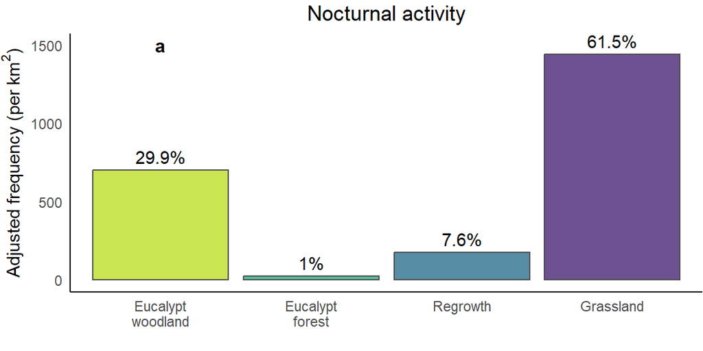

```r
noc_nvis_plot <- ggplot(noc_plot,
                        aes(x=mfws_habitat, y=freq_adj,
                            fill=mfws_habitat), col="grey30") +
  geom_col(size=0.5, col="grey30", alpha=0.8) +
  geom_text(aes(label = paste0(round(perc_adj, digits=1),
                               "%"), vjust=-0.5)) +
  annotate(geom="text", x=1, y=1500, label="a", fontface="bold", size=4) +
  theme(panel.grid.major = element_blank(),
        panel.grid.minor = element_blank(),
        panel.background = element_blank(),
        panel.border = element_blank(),
        plot.margin = unit(c(0.1, 0, 0, 0), "cm"),
        plot.title = element_text(hjust = 0.5),
        legend.position = "none",
        axis.ticks.x = element_blank(),
        axis.ticks.y = element_blank(),
        axis.text.x = element_text(vjust=1, hjust=0.5),
        axis.line.x = element_line(colour="black"),
        axis.line.y = element_line(colour="black")) +
  scale_fill_manual(values=viridis(4, begin=0.9, end=0.1)) +
  scale_x_discrete(labels=wrap_format(3)) +
  scale_y_continuous(limits=c(0, 1500)) +
  ggtitle("Nocturnal activity") + xlab("") +
  ylab(expression(paste("Adjusted frequency (per ", km^2, ")")))
print(noc_nvis_plot)
```

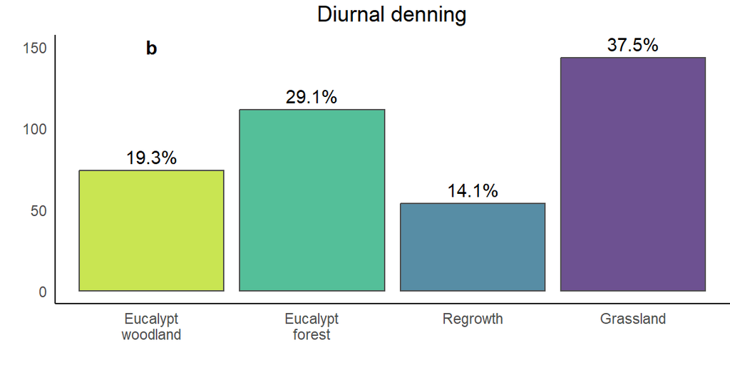

```r
diu_nvis_plot <- ggplot(diu_plot,
                        aes(x=mfws_habitat, y=freq_adj,
                            fill=mfws_habitat), col="grey30") +
  geom_col(size=0.5, col="grey30", alpha=0.8) +
  geom_text(aes(label = paste0(round(perc_adj, digits=1),
                               "%"), vjust=-0.5)) +
  annotate(geom="text", x=1, y=150, label="b", fontface="bold", size=4) +
  theme(panel.grid.major = element_blank(),
        panel.grid.minor = element_blank(),
        panel.background = element_blank(),
        panel.border = element_blank(),
        plot.margin = unit(c(0.1, 0, 0, 0), "cm"),
        plot.title = element_text(hjust = 0.5),
        legend.position = "none",
        axis.ticks.x = element_blank(),
        axis.ticks.y = element_blank(),
        axis.text.x = element_text(vjust=1, hjust=0.5),
        axis.line.x = element_line(colour="black"),
        axis.line.y = element_line(colour="black")) +
  scale_fill_manual(values=viridis(4, begin=0.9, end=0.1)) +
  scale_x_discrete(labels=wrap_format(3)) +
  scale_y_continuous(limits=c(0, 150)) +
  ggtitle("Diurnal denning") + xlab("") + ylab("")
print(diu_nvis_plot)
```

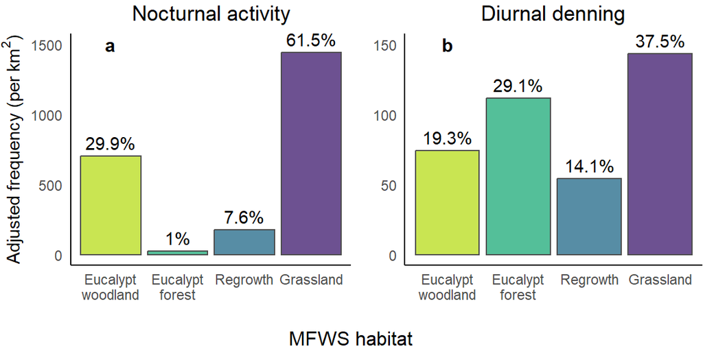

```r
nvis_plot <- ggarrange(noc_nvis_plot, diu_nvis_plot,
                       ncol=2, nrow=1, widths=c(3,3))
             annotate_figure(nvis_plot,
             bottom=textGrob("MFWS habitat", gp=gpar(cex=1)))
```

#### 6.3.2.2 Habitat attributes

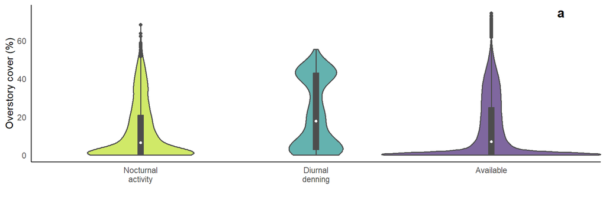

```r
lidar_os <- subset(lidar_plot, raster=="Overstory")
lidar_us <- subset(lidar_plot, raster=="Understory")
lidar_as <- subset(lidar_plot, raster=="Aspect")

lidar_os_plot <- ggplot(data=lidar_os,
                        aes(x=type, y=raster_units)) +
  geom_violin(position=pos, aes(fill=type),
              col="grey30", alpha=0.7, width=1.25, lwd=0.6) +
  geom_boxplot(position=pos, aes(col=type),
               fill="grey30", width=0.03, lwd=0.6) +
  stat_summary(position=pos, aes(col=type),
               fun="median", geom="point",
               fill="white", shape=21, size=1.5, stroke=1) +
  annotate(geom="text", x=3.4, y=75, label="a", fontface="bold", size=5) +
  theme(panel.grid.major = element_blank(),
        panel.grid.minor = element_blank(),
        panel.background = element_rect(fill="white"),
        axis.line = element_line(colour="black"),
        axis.ticks.x = element_blank(),
        axis.ticks.y = element_blank(),
        legend.position = "none") +
  scale_colour_manual(values=c("grey30","grey30","grey30")) +
  scale_fill_manual(values=viridis(3, begin=0.9, end=0.1)) +
  scale_x_discrete(labels=wrap_format(3)) + #library(scales) +
  xlab("") + ylab("Overstory cover (%)")
print(lidar_os_plot)
```

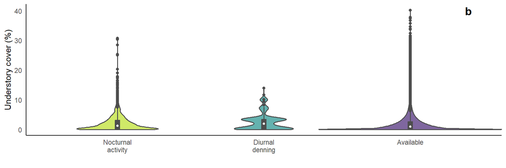

```r
lidar_us_plot <- ggplot(data=lidar_us,
                         aes(x=type, y=raster_units)) +
  geom_violin(position=pos, aes(fill=type),
              col="grey30", alpha=0.7, width=1.25, lwd=0.6) +
  geom_boxplot(position=pos, aes(col=type),
               fill="grey30", width=0.03, lwd=0.6) +
  stat_summary(position=pos, aes(col=type),
               fun="median", geom="point",
               fill="white", shape=21, size=1.5, stroke=1) +
  annotate(geom="text", x=3.4, y=40, label="b", fontface="bold", size=5) +
  theme(panel.grid.major = element_blank(),
        panel.grid.minor = element_blank(),
        panel.background = element_rect(fill="white"),
        axis.line = element_line(colour="black"),
        axis.ticks.x = element_blank(),
        axis.ticks.y = element_blank(),
        legend.position = "none") +
  scale_colour_manual(values=c("grey30","grey30","grey30")) +
  scale_fill_manual(values=viridis(3, begin=0.9, end=0.1)) +
  scale_x_discrete(labels=wrap_format(3)) + #library(scales) +
  xlab("") + ylab("Understory cover (%)")
print(lidar_us_plot)
```

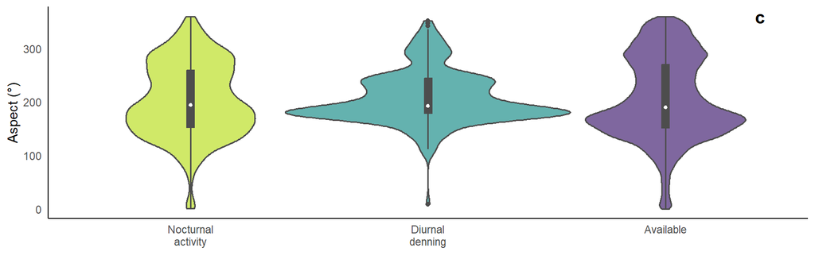

```r
lidar_as_plot <- ggplot(data=lidar_as,
                        aes(x=type, y=raster_units)) +
  geom_violin(position=pos, aes(fill=type),
              col="grey30", alpha=0.7, width=1.2, lwd=0.6) +
  geom_boxplot(position=pos, aes(col=type),
               fill="grey30", width=0.03, lwd=0.6) +
  stat_summary(position=pos, aes(col=type),
               fun="median", geom="point",
               fill="white", shape=21, size=1.5, stroke=1) +
  annotate(geom="text", x=3.4, y=360, label="c", fontface="bold", size=5) +
  theme(panel.grid.major = element_blank(),
        panel.grid.minor = element_blank(),
        panel.background = element_rect(fill="white"),
        axis.line = element_line(colour="black"),
        axis.ticks.x = element_blank(),
        axis.ticks.y = element_blank(),
        legend.position = "none") +
  scale_colour_manual(values=c("grey30","grey30","grey30")) +
  scale_x_discrete(labels = wrap_format(3)) + #library(scales) +
  scale_fill_manual(values = viridis(3, begin=0.9, end=0.1)) +
  xlab("") + ylab("Aspect (°)")
print(lidar_as_plot)
```

Plot understory and aspect by period.

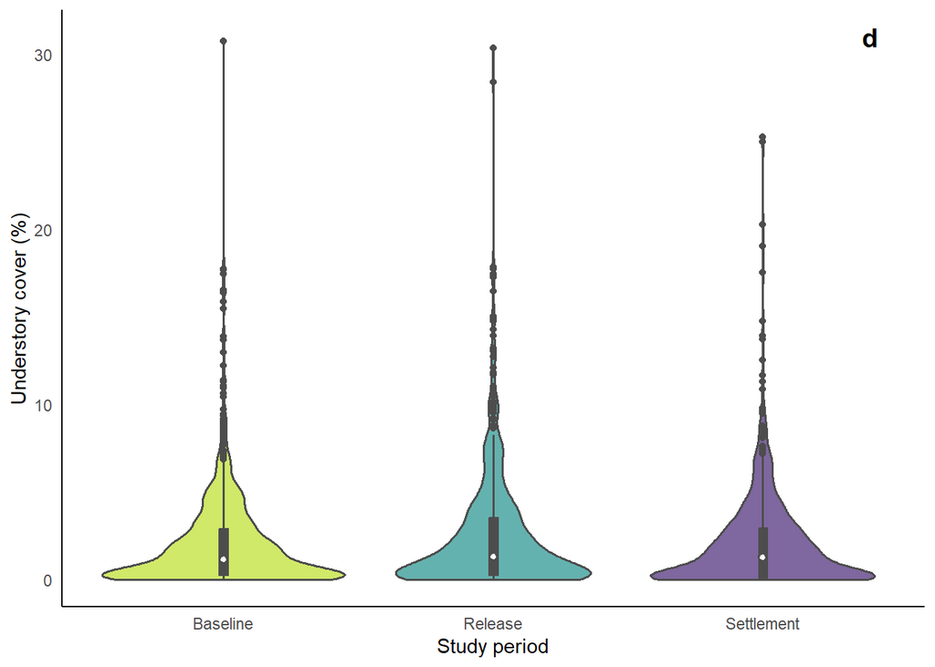

```r
lidar_us_period_noc <- ggplot(data=noc_lidar,
                              aes(x=period, y=understory*100)) +
  geom_violin(position=pos, aes(fill=period),
              col="grey30", alpha=0.7, lwd=0.6) +
  geom_boxplot(position=pos, aes(col=period),
               fill="grey30", width=0.03, lwd=0.6) +
  stat_summary(position=pos, aes(col=period),
               fun="median", geom="point",
               fill="white", shape=21, size=1.5, stroke=1) +
  annotate(geom="text", x=3.4, y=31, label="d", fontface="bold", size=5) +
  theme(panel.grid.major = element_blank(),
        panel.grid.minor = element_blank(),
        panel.background = element_rect(fill="white"),
        axis.line = element_line(colour="black"),
        axis.ticks.x = element_blank(),
        axis.ticks.y = element_blank(),
        plot.title = element_text(hjust = 0.5),
        legend.position = "none",
        strip.background = element_rect(colour="black", fill="grey30"),
        strip.text = element_text(colour="white")) +
  scale_colour_manual(values=c("grey30","grey30","grey30")) +
  scale_x_discrete(labels = wrap_format(3)) + #library(scales) +
  scale_fill_manual(values = viridis(3, begin=0.9, end=0.1)) +
  xlab("Study period") + ylab("Understory cover (%)")
print(lidar_us_period_noc)
```

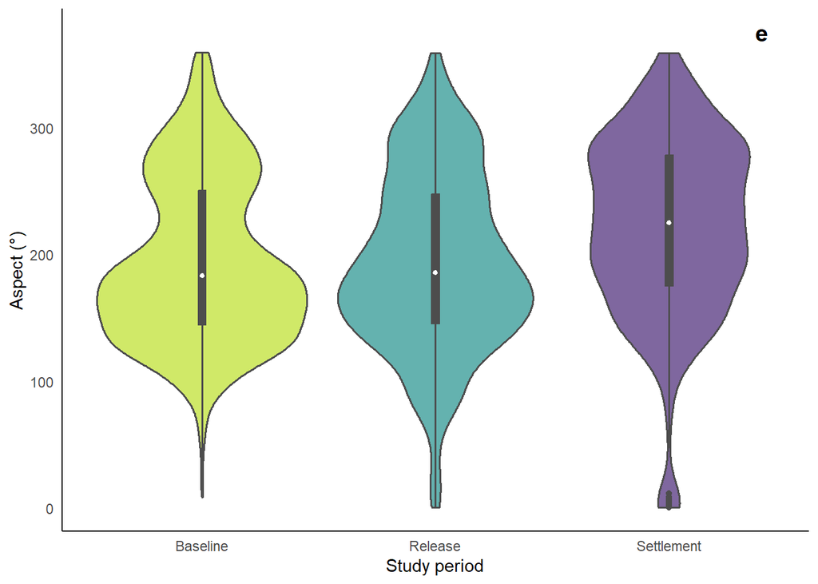

```r
lidar_as_period_noc <- ggplot(data=noc_lidar,
                              aes(x=period, y=aspect)) +
  geom_violin(position=pos, aes(fill=period),
              col="grey30", alpha=0.7, lwd=0.6) +
  geom_boxplot(position=pos, aes(col=period),
               fill="grey30", width=0.03, lwd=0.6) +
  stat_summary(position=pos, aes(col=period),
               fun="median", geom="point",
               fill="white", shape=21, size=1.5, stroke=1) +
  annotate(geom="text", x=3.4, y=375, label="e", fontface="bold", size=5) +
  theme(panel.grid.major = element_blank(),
        panel.grid.minor = element_blank(),
        panel.background = element_rect(fill="white"),
        axis.line = element_line(colour="black"),
        axis.ticks.x = element_blank(),
        axis.ticks.y = element_blank(),
        plot.title = element_text(hjust = 0.5),
        legend.position = "none") +
  scale_colour_manual(values=c("grey30","grey30","grey30")) +
  scale_x_discrete(labels = wrap_format(3)) + #library(scales) +
  scale_fill_manual(values = viridis(3, begin=0.9, end=0.1)) +
  xlab("Study period") + ylab("Aspect (°)")
print(lidar_as_period_noc)
```

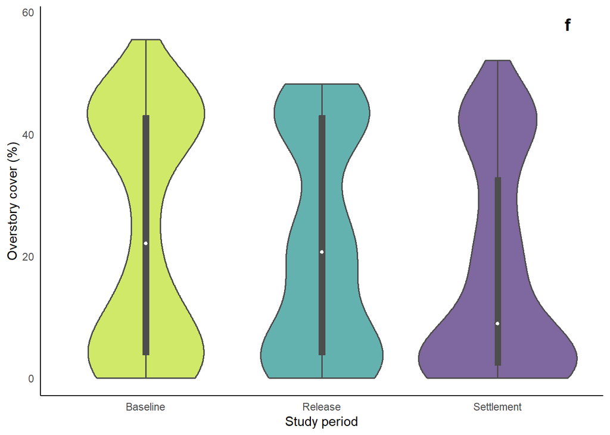

```r
lidar_os_period_diu <- ggplot(data=diu_lidar,
                              aes(x=period, y=overstory*100)) +
  geom_violin(position=pos, aes(fill=period),
              col="grey30", alpha=0.7, lwd=0.6) +
  geom_boxplot(position=pos, aes(col=period),
               fill="grey30", width=0.03, lwd=0.6) +
  stat_summary(position=pos, aes(col=period),
               fun="median", geom="point",
               fill="white", shape=21, size=1.5, stroke=1) +
  annotate(geom="text", x=3.4, y=58, label="f", fontface="bold", size=5) +
  theme(panel.grid.major = element_blank(),
        panel.grid.minor = element_blank(),
        panel.background = element_rect(fill="white"),
        axis.line = element_line(colour="black"),
        axis.ticks.x = element_blank(),
        axis.ticks.y = element_blank(),
        plot.title = element_text(hjust = 0.5),
        legend.position = "none") +
  scale_colour_manual(values=c("grey30","grey30","grey30")) +
  scale_x_discrete(labels = wrap_format(3)) + #library(scales) +
  scale_fill_manual(values = viridis(3, begin=0.9, end=0.1)) +
  xlab("Study period") + ylab("Overstory cover (%)")
print(lidar_os_period_diu)
```

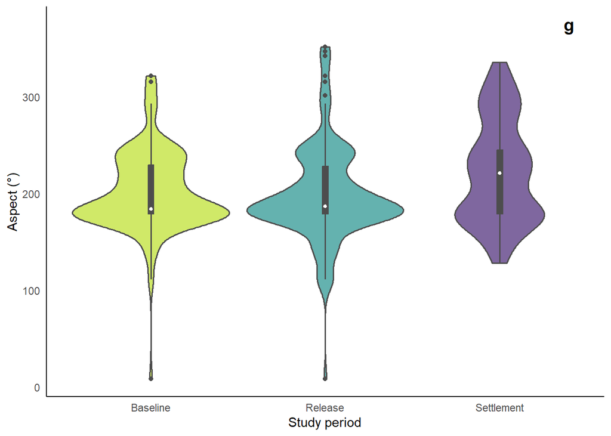

```r
lidar_as_period_diu <- ggplot(data=diu_lidar,
                          aes(x=period, y=aspect)) +
  geom_violin(position=pos, aes(fill=period),
              col="grey30", alpha=0.7, lwd=0.6) +
  geom_boxplot(position=pos, aes(col=period),
               fill="grey30", width=0.03, lwd=0.6) +
  stat_summary(position=pos, aes(col=period),
               fun="median", geom="point",
               fill="white", shape=21, size=1.5, stroke=1) +
  annotate(geom="text", x=3.4, y=375, label="g", fontface="bold", size=5) +
  theme(panel.grid.major = element_blank(),
        panel.grid.minor = element_blank(),
        panel.background = element_rect(fill="white"),
        axis.line = element_line(colour="black"),
        axis.ticks.x = element_blank(),
        axis.ticks.y = element_blank(),
        plot.title = element_text(hjust = 0.5),
        legend.position = "none") +
  scale_colour_manual(values=c("grey30","grey30","grey30")) +
  scale_x_discrete(labels = wrap_format(3)) + #library(scales) +
  scale_fill_manual(values = viridis(3, begin=0.9, end=0.1)) +
  xlab("Study period") + ylab("Aspect (°)")
print(lidar_as_period_diu)
```

# 7 **Conspecific associations**

## 7.1 Correlation coefficients

To quantify conspecific associations, we used the [wildlifeDI package](https://www.rdocumentation.org/packages/wildlifeDI/versions/0.4.1) to calculate:

- [Proximity index](https://www.rdocumentation.org/packages/wildlifeDI/versions/0.4.1/topics/Prox), the proportion of (simultaneous) fixes that are proximal, based on a distance threshold (Bertrand *et al.* 1996) using the `Prox()` function,
- [Pearson/Movement correlation coefficient](https://www.rdocumentation.org/packages/wildlifeDI/versions/0.4.1/topics/Cr), a Pearson product-moment correlation statistic (Shirabe 2006) using the `Cr()` function,
- [Coefficient of sociality](https://www.rdocumentation.org/packages/wildlifeDI/versions/0.4.1/topics/Cs) between two moving objects (Kenward *et al.* 1993) using a signed significance Wilcoxon-rank test with the `Cs()` function.
- [Coefficient of association](https://www.rdocumentation.org/packages/wildlifeDI/versions/0.4.1/topics/Ca), the dynamic interaction between two moving objects testing the number of fixes the animals are observed together against the total number of fixes where `Ca > 0.5` indicates affiliation or fidelity, while `Ca < 0.5` indicates no association between the two animals(Cole 1949, Bauman 1998).

### 7.1.1 Data curation

1. Study period

```r
data <- read.csv("output/coordinates curated.csv") %>%
  mutate(date_time_12hr=as.POSIXct(strptime(date_time_12hr,
                                            format="%Y-%m-%d %H:%M",
                                            tz="Australia/Sydney")))

data_ltraj <- as.ltraj(xy=data[,c("easting", "northing")],
                       date=data$date_time_12hr, id=data$name,
                       proj4string=CRS("EPSG:32755")) #plot(data_ltraj)

list <- data.frame((rep(c(1:15), each=15)), #change to unique(data$name)
                   (rep(c(1:15), times=15))) %>%
  rename(C1=1, C2=2) %>%
  subset(as.character(C1) != as.character(C2))

list1 <- list[,1]
list2 <- list[,2]
interact <- data.frame()

for (i in 1:length(list1)){

  try(prox <- data.frame(
    quoll1=attr(data_ltraj[[list1[i]]], "id"),
    quoll2=attr(data_ltraj[[list2[i]]], "id"),
    prox=Prox(data_ltraj[list1[i]], data_ltraj[list2[i]], tc=30*60, dc=50)),
    silent=TRUE)

  try(cr <- data.frame(
    quoll1=attr(data_ltraj[[list1[i]]], "id"),
    quoll2=attr(data_ltraj[[list2[i]]], "id"),
    cr=Cr(data_ltraj[list1[i]], data_ltraj[list2[i]], tc=30*60)),
    silent=TRUE)

  try(cs <- data.frame(
    quoll1=attr(data_ltraj[[list1[i]]], "id"),
    quoll2=attr(data_ltraj[[list2[i]]], "id"),
    cs=Cs(data_ltraj[list1[i]], data_ltraj[list2[i]], tc=30*60)),
    silent=TRUE)

  try(ca <- data.frame(
    quoll1=attr(data_ltraj[[list1[i]]], "id"),
    quoll2=attr(data_ltraj[[list2[i]]], "id"),
    ca=Ca(data_ltraj[list1[i]], data_ltraj[list2[i]], tc=30*60, dc=50)),
    silent=TRUE)

  out_cr <- left_join(prox, cr, by=c("quoll1", "quoll2"))
  out_cs <- left_join(out_cr, cs, by=c("quoll1", "quoll2"))
  out_ca <- left_join(out_cs, ca, by=c("quoll1", "quoll2"))
  print(out_ca[,1:3])
  interact <- rbind(interact, out_ca)
}

interact_study <- interact %>% #remove any duplicate pairs
  distinct(quoll1, quoll2, .keep_all=TRUE) %>%
  mutate(period=c("Study"), .after=quoll2)
```

2. Baseline period

```r
baseline <- data %>%
  filter(period=="Baseline") %>%
  droplevels()

data_ltraj <- as.ltraj(xy=baseline[,c("easting", "northing")],
                       date=baseline$date_time_12hr, id=baseline$name,
                       proj4string=CRS("EPSG:32755")) #plot(data_ltraj)

list <- data.frame((rep(c(1:7), each=7)), #change to unique(data$name)
                   (rep(c(1:7), times=7))) %>%
  rename(C1=1, C2=2) %>%
  subset(as.character(C1) != as.character(C2))

list1 <- list[,1]
list2 <- list[,2]
interact <- data.frame()

for (i in 1:length(list1)){

  try(prox <- data.frame(
    quoll1=attr(data_ltraj[[list1[i]]], "id"),
    quoll2=attr(data_ltraj[[list2[i]]], "id"),
    prox=Prox(data_ltraj[list1[i]], data_ltraj[list2[i]],
              tc=30*60, dc=50)),
    silent=TRUE)

  try(cr <- data.frame(
    quoll1=attr(data_ltraj[[list1[i]]], "id"),
    quoll2=attr(data_ltraj[[list2[i]]], "id"),
    cr=Cr(data_ltraj[list1[i]], data_ltraj[list2[i]],
          tc=30*60)),
    silent=TRUE)

  try(cs <- data.frame(
    quoll1=attr(data_ltraj[[list1[i]]], "id"),
    quoll2=attr(data_ltraj[[list2[i]]], "id"),
    cs=Cs(data_ltraj[list1[i]], data_ltraj[list2[i]],
          tc=30*60)),
    silent=TRUE)

  try(ca <- data.frame(
    quoll1=attr(data_ltraj[[list1[i]]], "id"),
    quoll2=attr(data_ltraj[[list2[i]]], "id"),
    ca=Ca(data_ltraj[list1[i]], data_ltraj[list2[i]],
          tc=30*60, dc=50)),
    silent=TRUE)

  out_cr <- left_join(prox, cr, by=c("quoll1", "quoll2"))
  out_cs <- left_join(out_cr, cs, by=c("quoll1", "quoll2"))
  out_ca <- left_join(out_cs, ca, by=c("quoll1", "quoll2"))
  print(out_ca[,1:3])
  interact <- rbind(interact, out_ca)
}

interact_baseline <- interact %>% #remove any duplicate pairs
  distinct(quoll1, quoll2, .keep_all=TRUE) %>%
  mutate(period=c("Baseline"), .after=quoll2)
```

3. Release period

```r
release <- data %>%
  filter(period=="Release") %>%
  droplevels()

data_ltraj <- as.ltraj(xy=release[,c("easting", "northing")],
                       date=release$date_time_12hr, id=release$name,
                       proj4string=CRS("EPSG:32755")) #plot(data_ltraj)

list <- data.frame((rep(c(1:14), each=14)), #change to unique(data$name)
                   (rep(c(1:14), times=14))) %>%
  rename(C1=1, C2=2) %>%
  subset(as.character(C1) != as.character(C2))

list1 <- list[,1]
list2 <- list[,2]
interact <- data.frame()

for (i in 1:length(list1)){

  try(prox <- data.frame(
    quoll1=attr(data_ltraj[[list1[i]]], "id"),
    quoll2=attr(data_ltraj[[list2[i]]], "id"),
    prox=Prox(data_ltraj[list1[i]], data_ltraj[list2[i]],
              tc=30*60, dc=50)),
    silent=TRUE)

  try(cr <- data.frame(
    quoll1=attr(data_ltraj[[list1[i]]], "id"),
    quoll2=attr(data_ltraj[[list2[i]]], "id"),
    cr=Cr(data_ltraj[list1[i]], data_ltraj[list2[i]],
          tc=30*60)),
    silent=TRUE)

  try(cs <- data.frame(
    quoll1=attr(data_ltraj[[list1[i]]], "id"),
    quoll2=attr(data_ltraj[[list2[i]]], "id"),
    cs=Cs(data_ltraj[list1[i]], data_ltraj[list2[i]],
          tc=30*60)),
    silent=TRUE)

  try(ca <- data.frame(
    quoll1=attr(data_ltraj[[list1[i]]], "id"),
    quoll2=attr(data_ltraj[[list2[i]]], "id"),
    ca=Ca(data_ltraj[list1[i]], data_ltraj[list2[i]],
          tc=30*60, dc=50)),
    silent=TRUE)

  out_cr <- left_join(prox, cr, by=c("quoll1", "quoll2"))
  out_cs <- left_join(out_cr, cs, by=c("quoll1", "quoll2"))
  out_ca <- left_join(out_cs, ca, by=c("quoll1", "quoll2"))
  print(out_ca[,1:3])
  interact <- rbind(interact, out_ca)
}

interact_release <- interact %>% #remove any duplicate pairs
  distinct(quoll1, quoll2, .keep_all=TRUE) %>%
  mutate(period=c("Release"), .after=quoll2)
```

4. Settlement period

```r
settlement <- data %>%
  filter(period=="Settlement") %>%
  droplevels()

data_ltraj <- as.ltraj(xy=settlement[,c("easting", "northing")],
                       date=settlement$date_time_12hr, id=settlement$name,
                       proj4string=CRS("EPSG:32755")) #plot(data_ltraj)

list <- data.frame((rep(c(1:10), each=10)), #change to unique(data$name)
                   (rep(c(1:10), times=10))) %>%
  rename(C1=1, C2=2) %>%
  subset(as.character(C1) != as.character(C2))

list1 <- list[,1]
list2 <- list[,2]
interact <- data.frame()

for (i in 1:length(list1)){

  try(prox <- data.frame(
    quoll1=attr(data_ltraj[[list1[i]]], "id"),
    quoll2=attr(data_ltraj[[list2[i]]], "id"),
    prox=Prox(data_ltraj[list1[i]], data_ltraj[list2[i]],
              tc=30*60, dc=50)),
    silent=TRUE)

  try(cr <- data.frame(
    quoll1=attr(data_ltraj[[list1[i]]], "id"),
    quoll2=attr(data_ltraj[[list2[i]]], "id"),
    cr=Cr(data_ltraj[list1[i]], data_ltraj[list2[i]],
          tc=30*60)),
    silent=TRUE)

  try(cs <- data.frame(
    quoll1=attr(data_ltraj[[list1[i]]], "id"),
    quoll2=attr(data_ltraj[[list2[i]]], "id"),
    cs=Cs(data_ltraj[list1[i]], data_ltraj[list2[i]],
          tc=30*60)),
    silent=TRUE)

  try(ca <- data.frame(
    quoll1=attr(data_ltraj[[list1[i]]], "id"),
    quoll2=attr(data_ltraj[[list2[i]]], "id"),
    ca=Ca(data_ltraj[list1[i]], data_ltraj[list2[i]],
          tc=30*60, dc=50)),
    silent=TRUE)

  out_cr <- left_join(prox, cr, by=c("quoll1", "quoll2"))
  out_cs <- left_join(out_cr, cs, by=c("quoll1", "quoll2"))
  out_ca <- left_join(out_cs, ca, by=c("quoll1", "quoll2"))
  print(out_ca[,1:3])
  interact <- rbind(interact, out_ca)
}

interact_settlement <- interact %>% #remove any duplicate pairs
  distinct(quoll1, quoll2, .keep_all=TRUE) %>%
  mutate(period=c("Settlement"), .after=quoll2)

interact <- rbind(interact_baseline, interact_release,
                  interact_settlement, interact_study)

write.csv(interact, "output/interaction coefficients.csv")
```

The `interact` dataframe now contains several dynamic interaction coefficients for each combination of quolls for each study period.

Now we add `cohort` and `morph` back into the dataframe using a `lookup`table, and averaged each of the coefficients per individual per `period` for our summary statistics.

```r
interact <- read.csv("output/interaction coefficients.csv") %>%
  mutate(name=quoll1) %>%
  na.omit() %>%
  merge(lookup, by=c("name", "period")) %>%
  mutate(cohort=factor(cohort, levels=c("Resident", "Reinforcer")),
         morph=factor(morph, levels=c("Fawn","Dark"))) %>%
  subset(period!="Study")
```

### 7.1.2 Models and summaries

Next we use GLMMs to test the fixed effects of `cohort`, `period`, and `morph` on the correlation coefficients. We did not include individual (`name`) as a random effect because there was a single `morph` for each.

```r
# Generate proximity index (prox)
mod <- glm(prox ~ cohort*period + morph,
           data=interact)
anova(mod) #residual deviance
```

```
## Analysis of Deviance Table
##
## Model: gaussian, link: identity
##
## Response: prox
##
## Terms added sequentially (first to last)
##
##
##               Df  Deviance Resid. Df Resid. Dev
## NULL                             243    0.94051
## cohort         1 0.0080229       242    0.93249
## period         2 0.0082246       240    0.92427
## morph          1 0.0018498       239    0.92242
## cohort:period  0 0.0000000       239    0.92242
```

```r
car::Anova(mod) #chisq, p-value
```

```
## Analysis of Deviance Table (Type II tests)
##
## Response: prox
##               LR Chisq Df Pr(>Chisq)
## cohort         0.08091  1     0.7761
## period         2.05359  2     0.3582
## morph          0.47929  1     0.4887
## cohort:period           0
```

```r
summary(mod) #t-value
```

```
##
## Call:
## glm(formula = prox ~ cohort * period + morph, data = interact)
##
## Coefficients: (2 not defined because of singularities)
##                                   Estimate Std. Error t value Pr(>|t|)
## (Intercept)                       0.006993   0.010204   0.685    0.494
## cohortReinforcer                  0.002989   0.010508   0.284    0.776
## periodRelease                     0.010490   0.012507   0.839    0.402
## periodSettlement                  0.022894   0.016445   1.392    0.165
## morphDark                         0.005651   0.008162   0.692    0.489
## cohortReinforcer:periodRelease          NA         NA      NA       NA
## cohortReinforcer:periodSettlement       NA         NA      NA       NA
##
## (Dispersion parameter for gaussian family taken to be 0.003859484)
##
##     Null deviance: 0.94051  on 243  degrees of freedom
## Residual deviance: 0.92242  on 239  degrees of freedom
## AIC: -656.57
##
## Number of Fisher Scoring iterations: 2
```

```r
# Generate pearson correlation index (cr)
mod <- glm(cr ~ cohort*period + morph,
           data=interact)
anova(mod) #residual deviance
```

```
## Analysis of Deviance Table
##
## Model: gaussian, link: identity
##
## Response: cr
##
## Terms added sequentially (first to last)
##
##
##               Df Deviance Resid. Df Resid. Dev
## NULL                            243     16.236
## cohort         1  0.00185       242     16.234
## period         2  0.50832       240     15.726
## morph          1  0.64912       239     15.076
## cohort:period  0  0.00000       239     15.076
```

```r
car::Anova(mod) #chisq, p-value
```

```
## Analysis of Deviance Table (Type II tests)
##
## Response: cr
##               LR Chisq Df Pr(>Chisq)
## cohort          3.2254  1   0.072505 .
## period          8.6573  2   0.013185 *
## morph          10.2901  1   0.001337 **
## cohort:period           0
## ---
## Signif. codes:  0 '***' 0.001 '**' 0.01 '*' 0.05 '.' 0.1 ' ' 1
```

```r
summary(mod) #t-value
```

```
##
## Call:
## glm(formula = cr ~ cohort * period + morph, data = interact)
##
## Coefficients: (2 not defined because of singularities)
##                                   Estimate Std. Error t value Pr(>|t|)
## (Intercept)                       -0.04427    0.04125  -1.073  0.28431
## cohortReinforcer                   0.07629    0.04248   1.796  0.07377 .
## periodRelease                     -0.06226    0.05056  -1.231  0.21942
## periodSettlement                  -0.17757    0.06649  -2.671  0.00809 **
## morphDark                          0.10586    0.03300   3.208  0.00152 **
## cohortReinforcer:periodRelease          NA         NA      NA       NA
## cohortReinforcer:periodSettlement       NA         NA      NA       NA
## ---
## Signif. codes:  0 '***' 0.001 '**' 0.01 '*' 0.05 '.' 0.1 ' ' 1
##
## (Dispersion parameter for gaussian family taken to be 0.06308169)
##
##     Null deviance: 16.236  on 243  degrees of freedom
## Residual deviance: 15.077  on 239  degrees of freedom
## AIC: 25.139
##
## Number of Fisher Scoring iterations: 2
```

```r
# Generate coefficient of sociality (cs)
mod <- glm(cs.Cs ~ cohort*period + morph,
           data=interact)
anova(mod) #residual deviance
```

```
## Analysis of Deviance Table
##
## Model: gaussian, link: identity
##
## Response: cs.Cs
##
## Terms added sequentially (first to last)
##
##
##               Df  Deviance Resid. Df Resid. Dev
## NULL                             243    0.32193
## cohort         1 0.0007684       242    0.32117
## period         2 0.0092370       240    0.31193
## morph          1 0.0039571       239    0.30797
## cohort:period  0 0.0000000       239    0.30797
```

```r
car::Anova(mod) #chisq, p-value
```

```
## Analysis of Deviance Table (Type II tests)
##
## Response: cs.Cs
##               LR Chisq Df Pr(>Chisq)
## cohort          2.4188  1    0.11989
## period          7.2871  2    0.02616 *
## morph           3.0709  1    0.07971 .
## cohort:period           0
## ---
## Signif. codes:  0 '***' 0.001 '**' 0.01 '*' 0.05 '.' 0.1 ' ' 1
```

```r
summary(mod) #t-value
```

```
##
## Call:
## glm(formula = cs.Cs ~ cohort * period + morph, data = interact)
##
## Coefficients: (2 not defined because of singularities)
##                                     Estimate Std. Error t value Pr(>|t|)
## (Intercept)                       -0.0001806  0.0058963  -0.031    0.976
## cohortReinforcer                   0.0094426  0.0060714   1.555    0.121
## periodRelease                      0.0035209  0.0072266   0.487    0.627
## periodSettlement                  -0.0128462  0.0095024  -1.352    0.178
## morphDark                          0.0082649  0.0047164   1.752    0.081 .
## cohortReinforcer:periodRelease            NA         NA      NA       NA
## cohortReinforcer:periodSettlement         NA         NA      NA       NA
## ---
## Signif. codes:  0 '***' 0.001 '**' 0.01 '*' 0.05 '.' 0.1 ' ' 1
##
## (Dispersion parameter for gaussian family taken to be 0.001288582)
##
##     Null deviance: 0.32193  on 243  degrees of freedom
## Residual deviance: 0.30797  on 239  degrees of freedom
## AIC: -924.24
##
## Number of Fisher Scoring iterations: 2
```

```r
# Generate coefficient of association (ca)
mod <- glm(ca ~ cohort*period + morph,
           data=interact)
anova(mod) #residual deviance
```

```
## Analysis of Deviance Table
##
## Model: gaussian, link: identity
##
## Response: ca
##
## Terms added sequentially (first to last)
##
##
##               Df   Deviance Resid. Df Resid. Dev
## NULL                              243   0.042479
## cohort         1 8.9717e-05       242   0.042389
## period         2 2.8377e-04       240   0.042105
## morph          1 3.9100e-06       239   0.042101
## cohort:period  0 0.0000e+00       239   0.042101
```

```r
car::Anova(mod) #chisq, p-value
```

```
## Analysis of Deviance Table (Type II tests)
##
## Response: ca
##               LR Chisq Df Pr(>Chisq)
## cohort         0.02555  1     0.8730
## period         1.59660  2     0.4501
## morph          0.02220  1     0.8816
## cohort:period           0
```

```r
summary(mod) #t-value
```

```
##
## Call:
## glm(formula = ca ~ cohort * period + morph, data = interact)
##
## Coefficients: (2 not defined because of singularities)
##                                     Estimate Std. Error t value Pr(>|t|)
## (Intercept)                        0.0031539  0.0021801   1.447    0.149
## cohortReinforcer                  -0.0003588  0.0022448  -0.160    0.873
## periodRelease                      0.0014162  0.0026719   0.530    0.597
## periodSettlement                   0.0040317  0.0035134   1.148    0.252
## morphDark                          0.0002598  0.0017438   0.149    0.882
## cohortReinforcer:periodRelease            NA         NA      NA       NA
## cohortReinforcer:periodSettlement         NA         NA      NA       NA
##
## (Dispersion parameter for gaussian family taken to be 0.0001761563)
##
##     Null deviance: 0.042479  on 243  degrees of freedom
## Residual deviance: 0.042101  on 239  degrees of freedom
## AIC: -1409.8
##
## Number of Fisher Scoring iterations: 2
```

**Summary statistics**

```r
# Pearson by period
interact %>%
  group_by(period) %>%
  summarise(mean=mean(cr), se=std.error(cr))
```

```
## # A tibble: 3 × 3
##   period         mean     se
##   <chr>         <dbl>  <dbl>
## 1 Baseline    0.00110 0.0207
## 2 Release    -0.0188  0.0243
## 3 Settlement -0.106   0.0290
```

```r
# Pearson by morph
interact %>%
  group_by(morph) %>%
  summarise(mean=mean(cr), se=std.error(cr))
```

```
## # A tibble: 2 × 3
##   morph    mean     se
##   <fct>   <dbl>  <dbl>
## 1 Fawn  -0.0764 0.0204
## 2 Dark   0.0258 0.0268
```

```r
# Sociality by period
interact %>%
  group_by(period) %>%
  summarise(mean=mean(cs.Cs), cs_se=std.error(cs.Cs))
```

```
## # A tibble: 3 × 3
##   period          mean   cs_se
##   <chr>          <dbl>   <dbl>
## 1 Baseline    0.00336  0.00155
## 2 Release     0.0122   0.00338
## 3 Settlement -0.000485 0.00471
```

On average, Pearson coefficients were significantly lower during the settlement periods (-0.106 ±0.0290 SE) than the baseline period (0.00110 ±0.0207 SE) and the release periods (-0.0188 ±0.0243 SE, *p* < 0.00809), and were significantly higher for dark morphs (0.0258 ±0.0268 SE) than for fawn morphs (-0.0764 ±0.0204 SE, *p* < 0.00152).

## 7.2 Den sharing

### 7.2.1 Models and summaries

```r
coden <- read_excel(raw_data, sheet="dens") %>%
  clean_names() %>%
  na.omit() %>%
  mutate(easting = as.numeric(easting),
         northing = as.numeric(northing),
         date = as.POSIXct(date_tracked),
         # Day of the year variable
         day = as.numeric(yday(date)),
         # Night variable
         night = (as.numeric(yday(date)) - 157),
         period = ifelse(night >=3 & night <=21, 'Baseline',
                  ifelse(night >=22 & night <=32, 'Release',
                  ifelse(night >=33 & night <=52, 'Settlement', NA)))) %>%
  # Remove irrelevant dates
  subset(night >=3 & night <=52) %>%
  subset(ifelse(cohort=="Resident", night <=32, night >=22)) %>%
  dplyr::select(name, morph, cohort, period, coden, eqd_code) %>%
  mutate(bin = ifelse(coden=="Alone", 0, 1)) %>%
  rename(den = eqd_code)

# Calculate frequency of den use
coden %>%
  group_by(den) %>%
  summarise(frequency=n()) %>%
  group_by(frequency) %>%
  summarise(dens=n())
```

```
## # A tibble: 17 × 2
##    frequency  dens
##        <int> <int>
##  1         1    13
##  2         2     9
##  3         3     2
##  4         4     4
##  5         5     3
##  6         6     4
##  7         7     2
##  8         8     2
##  9         9     2
## 10        10     1
## 11        13     2
## 12        15     1
## 13        20     1
## 14        22     2
## 15        23     1
## 16        39     1
## 17        96     1
```

```r
# Determine the most frequented den
megaden <- coden %>%
  filter(coden == "Den shared") %>%
  group_by(den) %>%
  summarise(frequency=n()) %>%
  filter(frequency == max(frequency))

# Determine which quolls frequented this den
coden %>%
  filter(den == megaden$den) %>%
  group_by(name, cohort) %>%
  summarise(number=n()) %>%
  arrange(number)
```

```
## # A tibble: 7 × 3
## # Groups:   name [7]
##   name     cohort     number
##   <chr>    <chr>       <int>
## 1 Indianna Reinforcer      1
## 2 Olive    Reinforcer      6
## 3 Elektra  Resident       11
## 4 Ebony    Resident       13
## 5 Nova     Reinforcer     18
## 6 Eevee    Resident       22
## 7 Delta    Resident       25
```

Of the 51 unique den sites, we found that 13 dens were used once, 28 were used on 2-9 occasions, 9 were used on 10-39 occasions, and one den (EQD-143) was used on 96 occasions. For three days in a row (Jul 27–29), this den was rested in by 5 collared eastern quolls at once (3 residents, 2 reinforcers).

Next we use GLMMs to test the fixed effects of `cohort`, `period`, and `morph` on the probability of den sharing. We did not include individual (`name`) as a random effect because there was a single `morph` for each.

```r
round(coef(summary(glm(bin ~ cohort + period + morph, data=coden,
                       family=binomial(link="logit")))), digits=4)
```

```
##                  Estimate Std. Error z value Pr(>|z|)
## (Intercept)       -2.2614     0.5592 -4.0437   0.0001
## cohortResident     2.4377     0.5195  4.6921   0.0000
## periodRelease      0.0475     0.2817  0.1687   0.8660
## periodSettlement   1.8551     0.5765  3.2180   0.0013
## morphFawn         -0.3711     0.2159 -1.7193   0.0856
```

```r
# Calculate frequency of den sharing per individual
sharing <- coden %>%
  group_by(name, cohort, period, morph, coden) %>%
  summarise(frequency=n())

# Calculate frequency of den sharing per cohort
sharing %>%
  group_by(cohort, coden) %>%
  summarise(frequency=sum(frequency))
```

```
## # A tibble: 4 × 3
## # Groups:   cohort [2]
##   cohort     coden      frequency
##   <chr>      <chr>          <int>
## 1 Reinforcer Alone            139
## 2 Reinforcer Den shared        50
## 3 Resident   Alone            114
## 4 Resident   Den shared       110
```

```r
# Calculate frequency of den sharing per period
sharing %>%
  group_by(period, coden) %>%
  summarise(frequency=sum(frequency))
```

```
## # A tibble: 6 × 3
## # Groups:   period [3]
##   period     coden      frequency
##   <chr>      <chr>          <int>
## 1 Baseline   Alone             75
## 2 Baseline   Den shared        71
## 3 Release    Alone             96
## 4 Release    Den shared        44
## 5 Settlement Alone             82
## 6 Settlement Den shared        45
```

```r
# Calculate probability of den sharing
sharing_plot <- sharing %>%
  spread(coden, frequency) %>%
  mutate(probability=(`Den shared`/sum(`Den shared`, Alone))) %>%
  mutate(cohort=factor(cohort, levels=c("Resident", "Reinforcer")))
```

**Summary statistics**

We found residents were significantly more likely to share their diurnal dens with other collared eastern quolls (*p* < 0.0001), spending an average of 51.7% their days den sharing compared to 28.6% for reinforcers.

Two collared eastern quolls den shared only once (both reinforcers), six (five of which were reinforcers) den shared on 2-6 occasions, and six (four of which were residents) den shared on 11-20 occasions, and two den shared on 22 occasions each (both residents).

```r
# Den sharing by period
sharing_plot %>%
  na.omit() %>%
  group_by(period) %>%
  summarise(mean=mean(probability*100),
            se=std.error(probability*100))
```

```
## # A tibble: 3 × 3
##   period      mean    se
##   <chr>      <dbl> <dbl>
## 1 Baseline    54.7  7.73
## 2 Release     40.0  9.96
## 3 Settlement  33.4 10.1
```

```r
# Den sharing by cohort
sharing_plot %>%
  na.omit() %>%
  group_by(cohort) %>%
  summarise(mean=mean(probability*100),
            se=std.error(probability*100))
```

```
## # A tibble: 2 × 3
##   cohort      mean    se
##   <fct>      <dbl> <dbl>
## 1 Resident    51.7  7.26
## 2 Reinforcer  28.6  7.67
```

## 7.3 Plots

Finally, we plot these significant results.

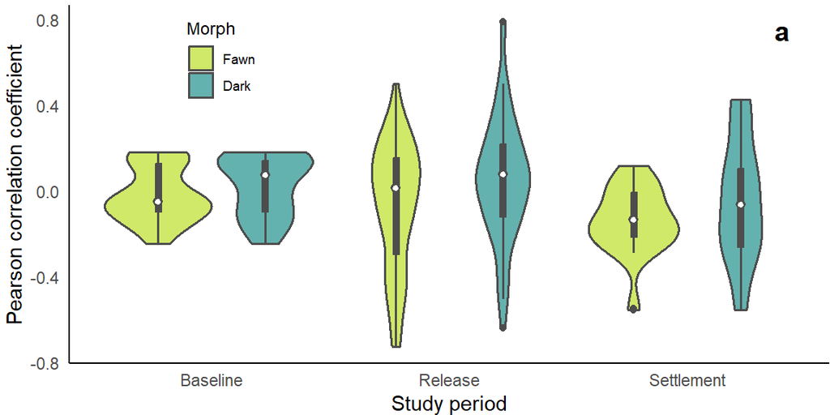

```r
pear_period_plot <- ggplot(data=interact,
                           aes(x=period, y=as.numeric(cr))) +
  geom_violin(position=pos, aes(fill=morph),
              col="grey30", alpha=0.7, lwd=0.6) +
  geom_boxplot(position=pos, aes(col=morph),
               fill="grey30", width=0.04, lwd=0.6) +
  stat_summary(position=pos, aes(col=morph),
               fun="median", geom="point",
               fill="white", shape=21, size=1.5, stroke=1) +
  annotate(geom="text", x=3.4, y=0.75, label="a", fontface="bold", size=5) +
  theme(panel.grid.major = element_blank(),
        panel.grid.minor = element_blank(),
        panel.background = element_rect(fill="white"),
        plot.margin = unit(c(0.1, 0, 0, 0.1), "cm"),
        axis.line = element_line(colour="black"),
        axis.ticks.x = element_blank(),
        axis.ticks.y = element_blank(),
        legend.position=c(0.2, 0.85),
        legend.title = element_text(size=9),
        legend.text = element_text(size=7),
        legend.key = element_rect(fill = NA),
        legend.key.height = unit(0.5, 'cm'),
        legend.key.width = unit(0.5, 'cm'),
        legend.background=element_blank()) +
  scale_colour_manual(values=c("grey30","grey30")) +
  scale_fill_manual(values = viridis(3, begin=0.9, end=0.1)) +
  xlab("Study period") +
  ylab("Pearson correlation coefficient") +
  labs(fill="Morph") + guides(colour="none")
print(pear_period_plot)
```

[figure not shown]

```r
soc_period_plot <- ggplot(data=interact,
                          aes(x=period, y=as.numeric(cr))) +
  geom_violin(position=pos, aes(fill=period),
              col="grey30", alpha=0.7, lwd=0.6) +
  geom_boxplot(position=pos, aes(col=period),
               fill="grey30", width=0.03, lwd=0.6) +
  stat_summary(position=pos, aes(col=period),
               fun="median", geom="point",
               fill="white", shape=21, size=1.5, stroke=1) +
  annotate(geom="text", x=3.4, y=0.75, label="b", fontface="bold", size=5) +
  theme(panel.grid.major = element_blank(),
        panel.grid.minor = element_blank(),
        panel.background = element_rect(fill="white"),
        plot.margin = unit(c(0.1, 0, 0, 0.1), "cm"),
        axis.line = element_line(colour="black"),
        axis.ticks.x = element_blank(),
        axis.ticks.y = element_blank(),
        legend.position = "none",
        legend.background=element_blank()) +
  scale_colour_manual(values=c("grey30","grey30","grey30")) +
  scale_fill_manual(values = viridis(3, begin=0.9, end=0.1)) +
  xlab("Study period") + ylab("Coefficient of sociality")
print(soc_period_plot)
```

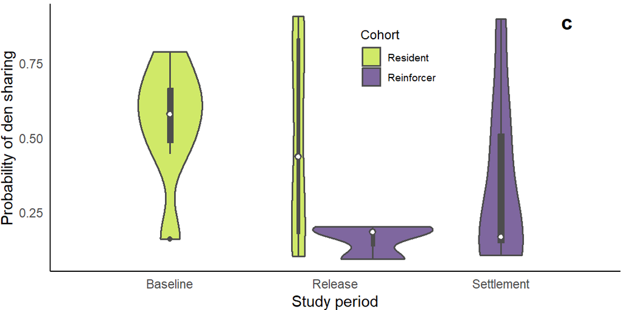

```r
coden_plot <- ggplot(data=sharing_plot,
                      aes(x=period, y=as.numeric(probability))) +
  geom_violin(position=pos, aes(fill=cohort),
              col="grey30", alpha=0.7, width=1.45, lwd=0.6) +
  geom_boxplot(position=pos, aes(col=cohort),
               fill="grey30", width=0.03, lwd=0.6) +
  stat_summary(position=pos, aes(col=cohort),
               fun="median", geom="point",
               fill="white", shape=21, size=1.5, stroke=1) +
  annotate(geom="text", x=3.4, y=0.89, label="c", fontface="bold", size=5) +
  theme(panel.grid.major = element_blank(),
        panel.grid.minor = element_blank(),
        panel.background = element_rect(fill="white"),
        plot.margin = unit(c(0.1, 0, 0, 0), "cm"),
        axis.line = element_line(colour="black"),
        axis.ticks.x = element_blank(),
        axis.ticks.y = element_blank(),
        legend.position=c(0.61, 0.8),
        legend.title = element_text(size=9),
        legend.text = element_text(size=7),
        legend.key = element_rect(fill = NA),
        legend.key.height = unit(0.5, 'cm'),
        legend.key.width = unit(0.5, 'cm'),
        legend.background=element_blank()) +
  scale_colour_manual(values=c("grey30","grey30")) +
  scale_fill_manual(values = viridis(2, begin=0.9, end=0.1)) +
  xlab("Study period") + ylab("Probability of den sharing") +
  labs(fill="Cohort") + guides(colour="none")
print(coden_plot)
```

# 8 **Animation**

Following the [gganimate tutorial by Katherine Goode](https://goodekat.github.io/presentations/2019-isugg-gganimate-spooky/slides.html?fbclid=IwAR0xBuMZO0ZCKjx2SF6hTPL5lv8JMfALIlmwopA_QmqGddCuN6jab3msWsY#1), we created an animation showing the movement of the eastern quolls over the study period - ⚠️ *currently not running.*